# A Tool for Detecting Prostate Cancer

Version: 10.1

Program: R

Libraries used: dplyr glmnet cluster e1071 class caret MASS tree RColorBrewer randomForest

## Introduction

The dataset that will be used contains information about prostate cancer. Each of the observation contains information on the type of cancer stage based on different attributes. In order to correctly identify the type of cancer stage the observation results to, different types of classification methods will be used.

```r
#Load libraries
library(dplyr)
library(glmnet)
library(cluster)
library(e1071)
library(class)
library(caret)
library(MASS)
library(tree)
library(RColorBrewer)
library(randomForest)
```

## Exploring the data set

```r
dat <- read.csv('data3000Final.csv') #reading in the comma seperated value file as dat
```

#### Viewing the data set

```r
cat('Viewing the data\n')
head(dat, 5) #viewing the first 5 rows of the dataset
cat('Data types\n')
str(dat)
cat('\nStatistical minimum and maximum of the columns\n')
data.frame(Minimum = apply(dat, 2, min), Maximum = apply(dat, 2, max)) # find only the maximum and minimum
cat("\nUnique Attributes for '?' containing columns\n")
t(apply(dat[,c('ATT1','ATT3', 'ATT4', 'ATT5')], 2, unique)) #printing unique values
```

```
Viewing the data
```

|  | ID | ATT1 | ATT2 | ATT3 | ATT4 | ATT5 | ATT6 | ATT7 | ATT8 | ATT9 | ATT10 | Result |
| --- | --- | --- | --- | --- | --- | --- | --- | --- | --- | --- | --- | --- |
| 1 | 1 | 1 | 4 | 1 | 4 | 3 | 7 | 1 | 2 | 6 | 8 | 0 |
| 2 | 2 | ? | 8 | 9 | 1 | 1 | 1 | 1 | 5 | 6 | 1 | 1 |
| 3 | 3 | 10 | 7 | ? | 7 | ? | 5 | 2 | 7 | 1 | 1 | 2 |
| 4 | 4 | 3 | 4 | 3 | ? | 2 | 8 | 4 | 6 | 7 | 2 | 1 |
| 5 | 5 | 3 | 5 | 2 | 1 | 6 | 5 | 3 | 1 | 7 | 1 | 0 |

```
Data types
'data.frame':	3000 obs. of  12 variables:
 $ ID    : int  1 2 3 4 5 6 7 8 9 10 ...
 $ ATT1  : Factor w/ 11 levels "?","1","10","2",..: 2 1 3 5 5 4 2 10 4 2 ...
 $ ATT2  : int  4 8 7 4 5 7 1 5 9 1 ...
 $ ATT3  : Factor w/ 11 levels "?","1","10","2",..: 2 11 1 5 4 5 5 4 4 2 ...
 $ ATT4  : Factor w/ 11 levels "?","1","10","2",..: 6 2 9 1 2 4 7 8 2 10 ...
 $ ATT5  : Factor w/ 11 levels "?","1","10","2",..: 5 2 1 4 8 2 11 4 6 11 ...
 $ ATT6  : int  7 1 5 8 5 4 3 7 6 2 ...
 $ ATT7  : int  1 1 2 4 3 10 7 3 8 2 ...
 $ ATT8  : int  2 5 7 6 1 3 1 6 8 5 ...
 $ ATT9  : int  6 6 1 7 7 9 10 7 4 1 ...
 $ ATT10 : int  8 1 1 2 1 5 7 3 3 3 ...
 $ Result: int  0 1 2 1 0 1 1 1 1 0 ...

Statistical minimum and maximum of the columns
```

|  | Minimum | Maximum |
| --- | --- | --- |
| ID | 1 | 3000 |
| ATT1 | ? | 9 |
| ATT2 | 1 | 10 |
| ATT3 | ? | 9 |
| ATT4 | ? | 9 |
| ATT5 | ? | 9 |
| ATT6 | 1 | 10 |
| ATT7 | 1 | 10 |
| ATT8 | 1 | 10 |
| ATT9 | 1 | 10 |
| ATT10 | 1 | 10 |
| Result | 0 | 3 |

```
Unique Attributes for '?' containing columns
```

| ATT1 | 1 | ? | 10 | 3 | 2 | 8 | 9 | 6 | 5 | 7 | 4 |
| --- | --- | --- | --- | --- | --- | --- | --- | --- | --- | --- | --- |
| ATT3 | 1 | 9 | ? | 3 | 2 | 5 | 8 | 7 | 10 | 6 | 4 |
| ATT4 | 4 | 1 | 7 | ? | 2 | 5 | 6 | 8 | 10 | 9 | 3 |
| ATT5 | 3 | 1 | ? | 2 | 6 | 9 | 4 | 7 | 8 | 5 | 10 |

#### Summary of the laboratory dataset:

The dataset contains 3000 observations of prostate cancer laboratory data. Of the 12 columns, 10 of the columns contain numerical feature of the cancer. The other 2 columns are the unique identifier (ID), in number, of each observations, and the other one is the result (result) of each observations, ranging from 0 to 3.

| Attributes | Data Types | Comments |
| --- | --- | --- |
| ID | int | The unique identification number for each rows, ranging from 1 to 3000 |
| ATT1 | factor | Column contains '?' and number from 1 to 10, 11 levels |
| ATT2 | int | Attribute contains whole number from 1 to 10 |
| ATT3 | factor | Column contains '?' and number from 1 to 10, 11 levels |
| ATT4 | factor | Column contains '?' and number from 1 to 10, 11 levels |
| ATT5 | factor | Column contains '?' and number from 1 to 10, 11 levels |
| ATT6 | int | Attribute contains whole number from 1 to 10 |
| ATT7 | int | Attribute contains whole number from 1 to 10 |
| ATT8 | int | Attribute contains whole number from 1 to 10 |
| ATT9 | int | Attribute contains whole number from 1 to 10 |
| ATT10 | int | Attribute contains whole number from 1 to 10 |
| Result | int | Attribute is dependent, contains information on the result of the observation, ranging from 0 to 3. More information are shown below. |

**Attribute: Result**

| Class attribute | Comments |
| --- | --- |
| 0 | Curable |
| 1 | Tumour stage |
| 2 | Node stage |
| 3 | Incurable cancers |

#### Row counts for each cases

```r
# counting the number of rows for each cancer case/class
for(i in 0:3){
    cat('\nNumber of rows when Result is', i, 'is', nrow(dat[dat$Result == as.character(i),]))
}
```

```
Number of rows when Result is 0 is 1082
Number of rows when Result is 1 is 1080
Number of rows when Result is 2 is 642
Number of rows when Result is 3 is 196
```

# Task 1: Predict Missing Values

#### Identifying rows that have missing values and duplicated columns

As shown, beside some rows containing '?', there are no rows with missing values for any of the columns. All '?' cell will be replaced with NA, which would better indicate the missingness of the values.

```r
dup <- dat[,-1]
cat('There are', sum(duplicated(dup[nrow(dup):1, ])[nrow(dup):1]), 'number of duplicate rows\n')
cat('\nNumber of missing values in each rows')
t(sapply(dat, function(x) sum(is.na(x)))) #summing all missing values for each column
```

```
There are 0 number of duplicate rows

Number of missing values in each rows
```

| ID | ATT1 | ATT2 | ATT3 | ATT4 | ATT5 | ATT6 | ATT7 | ATT8 | ATT9 | ATT10 | Result |
| --- | --- | --- | --- | --- | --- | --- | --- | --- | --- | --- | --- |
| 0 | 0 | 0 | 0 | 0 | 0 | 0 | 0 | 0 | 0 | 0 | 0 |

```r
dat[dat == '?'] <- NA # assign all '?' as NA
cat('The amount of missing value are indicated by TRUE:')
print(table(is.na(dat)))
cat("\nThe missing values were those four identified '?'\n")
head(dat[colSums(is.na(dat)) > 0], 4) #output cells that have more than 0 NA
```

```
The amount of missing value are indicated by TRUE:
FALSE  TRUE
35996     4

The missing values were those four identified '?'
```

|  | ATT1 | ATT3 | ATT4 | ATT5 |
| --- | --- | --- | --- | --- |
| 1 | 1 | 1 | 4 | 3 |
| 2 | NA | 9 | 1 | 1 |
| 3 | 10 | NA | 7 | NA |
| 4 | 3 | 3 | NA | 2 |

As show above, the there were only four '?' in the dataset, in which those four were replaced by NA to better represent the missing values.

#### Converting the column with missing value data type of factor to int

Previously, the ATT1, ATT3, ATT4, ATT5 were in factor form due to the presence of the character '?'. Since all of the ATT are predictors of the result in numerical form, those four columns should have the same dataset as the others as well for numerical prediction and computational purposes.

```r
dat[,c('ATT1', 'ATT3', 'ATT4', 'ATT5')] <- lapply(dat[, c('ATT1', 'ATT3', 'ATT4', 'ATT5')],
                                                     function(x) as.integer(as.character(x))) #convert data type to int
cat('Data type\n')
str(dat)
```

```
Data type
'data.frame':	3000 obs. of  12 variables:
 $ ID    : int  1 2 3 4 5 6 7 8 9 10 ...
 $ ATT1  : int  1 NA 10 3 3 2 1 8 2 1 ...
 $ ATT2  : int  4 8 7 4 5 7 1 5 9 1 ...
 $ ATT3  : int  1 9 NA 3 2 3 3 2 2 1 ...
 $ ATT4  : int  4 1 7 NA 1 2 5 6 1 8 ...
 $ ATT5  : int  3 1 NA 2 6 1 9 2 4 9 ...
 $ ATT6  : int  7 1 5 8 5 4 3 7 6 2 ...
 $ ATT7  : int  1 1 2 4 3 10 7 3 8 2 ...
 $ ATT8  : int  2 5 7 6 1 3 1 6 8 5 ...
 $ ATT9  : int  6 6 1 7 7 9 10 7 4 1 ...
 $ ATT10 : int  8 1 1 2 1 5 7 3 3 3 ...
 $ Result: int  0 1 2 1 0 1 1 1 1 0 ...
```

#### Correlation

The correlation matrix can be plotted after converting the attribute to its respective data types. The correlation table is shown below.

|  | ID | ATT1 | ATT2 | ATT3 | ATT4 | ATT5 | ATT6 | ATT7 | ATT8 | ATT9 | ATT10 | Result |
| --- | --- | --- | --- | --- | --- | --- | --- | --- | --- | --- | --- | --- |
| ID | 1 |  |  | -0.0115764419103677 | -0.0130833571884232 |  |  |  | 0.0112808656661366 |  | -0.0115768079047462 | -0.0109165174031685 |
| ATT1 |  | 1 | 0.0461049280254728 | 0.0806051466537306 | 0.0560172000134565 | 0.0442230755764816 | 0.0545217677356426 | 0.0712257784807624 | 0.050263512194771 | 0.0541873347905424 | 0.0546829706823575 | 0.374262650094754 |
| ATT2 |  | 0.0461049280254728 | 1 | 0.0670962995218319 | 0.0615734281879027 | 0.031692981420267 | 0.0393636054690684 | 0.0112175728591804 | 0.0297401031429886 | 0.0942429254047603 | 0.0727165421456435 | 0.351255005844948 |
| ATT3 | -0.0115764419103677 | 0.0806051466537306 | 0.0670962995218319 | 1 | 0.0465680631334471 | 0.0649855264708986 | 0.0401791674775182 | 0.0314436283205823 | 0.0260281366675682 | 0.0602964724297565 | 0.0854302411325491 | 0.365252456267799 |
| ATT4 | -0.0130833571884232 | 0.0560172000134565 | 0.0615734281879027 | 0.0465680631334471 | 1 | 0.0800300073096667 | 0.0454709810269798 | 0.0586017043063114 | 0.0212505289153697 | 0.0280173082789074 | 0.0826484914767351 | 0.360354160130761 |
| ATT5 |  | 0.0442230755764816 | 0.031692981420267 | 0.0649855264708986 | 0.0800300073096667 | 1 | 0.0499585945400154 | 0.0714398461547858 | 0.0290759349277754 | 0.0837331216766697 | 0.083607320540306 | 0.3742799436104 |
| ATT6 |  | 0.0545217677356426 | 0.0393636054690684 | 0.0401791674775182 | 0.0454709810269798 | 0.0499585945400154 | 1 | 0.0231553663088315 | 0.0407804315558116 | 0.0672870982916474 | 0.0628140109027259 | 0.333836068796173 |
| ATT7 |  | 0.0712257784807624 | 0.0112175728591804 | 0.0314436283205823 | 0.0586017043063114 | 0.0714398461547858 | 0.0231553663088315 | 1 | 0.0782321833065353 | 0.0372132902574474 | 0.066583679029015 | 0.340612103524528 |
| ATT8 | 0.0112808656661366 | 0.050263512194771 | 0.0297401031429886 | 0.0260281366675682 | 0.0212505289153697 | 0.0290759349277754 | 0.0407804315558116 | 0.0782321833065353 | 1 | 0.0431909011330903 | 0.0337757787297562 | 0.327104805335433 |
| ATT9 |  | 0.0541873347905424 | 0.0942429254047603 | 0.0602964724297565 | 0.0280173082789074 | 0.0837331216766697 | 0.0672870982916474 | 0.0372132902574474 | 0.0431909011330903 | 1 | 0.0118541085590571 | 0.349590229281885 |
| ATT10 | -0.0115768079047462 | 0.0546829706823575 | 0.0727165421456435 | 0.0854302411325491 | 0.0826484914767351 | 0.083607320540306 | 0.0628140109027259 | 0.066583679029015 | 0.0337757787297562 | 0.0118541085590571 | 1 | 0.373089202683985 |
| Result | -0.0109165174031685 | 0.374262650094754 | 0.351255005844948 | 0.365252456267799 | 0.360354160130761 | 0.3742799436104 | 0.333836068796173 | 0.340612103524528 | 0.327104805335433 | 0.349590229281885 | 0.373089202683985 | 1 |

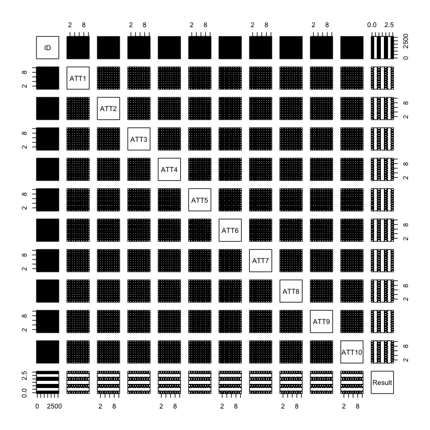

```r
cor <- as.matrix(cor(na.omit(dat)))
cor[(cor < 0.01) & (cor > -0.01)] <- '' #only show non-NA correlation values
corel <- as.data.frame(cor)
corel
plot(na.omit(dat)) #plot scatterplot matrix
```

#### Correlation Summary

The correlation matrix and scatterplot showed that there are insignificant statistical correlation between attributes. The strongest correlation, which is still a weak correlation occurs between result and other variables [4], where all of the correlation between it and the predictors are positively correlated.

#### Dealing with the missing value

There are conventional methods to deal with missing value and that is to:

Deletion

This methods includes deleting the rows which contains the missing values. The advantage of this method is that it's quick and easy, it doesnt not require any computational methods. However the disadvantage is that valuable observations are lost. This case would work well if the missing values are missing completely at random (MCAR).

Imputation

There are two types if imputation, which is the mean imputation and the conditional mean imputation.

- *The normal mean imputation* is computed based on the mean of the column, however this results in bias.

*Given the formular f(y) = x1, x2, x3...xn*

- *The conditional mean imputation* uses other independent variables to estimate the value for the missing values. The rows that have complete case (complete information, no missing values) are used to regress X on all other independent variable, then using the estimated equation to predict for the missing x (missing value).
- However some limitations to this method includes the underestimation of the standard error and the overestimation of the test statistics, where the value is determined completely by the model that was used and this results in a case where the standard error is ignored. In order to overcome this challenge, *multiple imputation* can be used. This includes doing multiple prediction of the missing value, adding additional form of error which is based on variations in the parameter estimates across the imputation (imputation error). Though multiple imputation will not be computed as it is not within the scope of what was studied.

#### Missing values analysis

NOTE: *rows* will be refered to as *observations*

### Preparing the dataset for the regression analysis

#### Removing ID and result columns.

There are two different ways to determine the missing value through imputation, and some regression includes the use of the dependent variable (result) as well as other predictors, while some does not. [1] Explained that the dependent variable should not be used to train the mean regression model, [2] also stated the same, however some other articles such as [3] indicated that it should be used in imputation.

#### Imputation of the missing value explain

To impute the missing values, different regression models will be used. Since there are little to no relationshop between the predicting attributes and the resonse attribute, which is the value that is to be imputed, a linear regression model will not be used as the slope of it would be highly small, which would lead to odd values.

#### Benchmark Measurement

The mean square error (expected value for the square error loss) will be used as a benchmark measurement to determine which of the models will produce the most accurate value of the missing value.

The response variable will be the single column that contains the missing value. For example, in the first case of missing value, ATT1 contains missing value. All the other predictors beside ATT1 will be used as the predictor.

In order to solve the problem with using or not using the dependent variable, 'result', the variable will be included in the first prediction of the missing value, and determine which results in a lower MSE. Nevertheless, the redundant variable ID will be removed as it serves no purpose in prediction.

```r
flt_dat <- dat[-c(1, length(dat))] #subsetting ID and result from column
flt_dat_res <- dat[-1]
cat('With Result\n')
head(flt_dat_res, 5)
cat('Without Result\n')
head(flt_dat, 5)
```

```
With Result
```

|  | ATT1 | ATT2 | ATT3 | ATT4 | ATT5 | ATT6 | ATT7 | ATT8 | ATT9 | ATT10 | Result |
| --- | --- | --- | --- | --- | --- | --- | --- | --- | --- | --- | --- |
| 1 | 1 | 4 | 1 | 4 | 3 | 7 | 1 | 2 | 6 | 8 | 0 |
| 2 | NA | 8 | 9 | 1 | 1 | 1 | 1 | 5 | 6 | 1 | 1 |
| 3 | 10 | 7 | NA | 7 | NA | 5 | 2 | 7 | 1 | 1 | 2 |
| 4 | 3 | 4 | 3 | NA | 2 | 8 | 4 | 6 | 7 | 2 | 1 |
| 5 | 3 | 5 | 2 | 1 | 6 | 5 | 3 | 1 | 7 | 1 | 0 |

```
Without Result
```

|  | ATT1 | ATT2 | ATT3 | ATT4 | ATT5 | ATT6 | ATT7 | ATT8 | ATT9 | ATT10 |
| --- | --- | --- | --- | --- | --- | --- | --- | --- | --- | --- |
| 1 | 1 | 4 | 1 | 4 | 3 | 7 | 1 | 2 | 6 | 8 |
| 2 | NA | 8 | 9 | 1 | 1 | 1 | 1 | 5 | 6 | 1 |
| 3 | 10 | 7 | NA | 7 | NA | 5 | 2 | 7 | 1 | 1 |
| 4 | 3 | 4 | 3 | NA | 2 | 8 | 4 | 6 | 7 | 2 |
| 5 | 3 | 5 | 2 | 1 | 6 | 5 | 3 | 1 | 7 | 1 |

#### Estimating missing value for ATT1

To estimate the missing value for ATT1, all rows that contains the missing value will be omited from the data to create a complete case environment to train and build the model.

```r
ATT1_dat <-na.omit(flt_dat) #remove all rows with NA
ATT1_dat_res <-na.omit(flt_dat_res)
cat('With Result\n')
head(ATT1_dat, 5)
cat('Without Result\n')
head(ATT1_dat_res, 5)
```

```
With Result
```

|  | ATT1 | ATT2 | ATT3 | ATT4 | ATT5 | ATT6 | ATT7 | ATT8 | ATT9 | ATT10 |
| --- | --- | --- | --- | --- | --- | --- | --- | --- | --- | --- |
| 1 | 1 | 4 | 1 | 4 | 3 | 7 | 1 | 2 | 6 | 8 |
| 5 | 3 | 5 | 2 | 1 | 6 | 5 | 3 | 1 | 7 | 1 |
| 6 | 2 | 7 | 3 | 2 | 1 | 4 | 10 | 3 | 9 | 5 |
| 7 | 1 | 1 | 3 | 5 | 9 | 3 | 7 | 1 | 10 | 7 |
| 8 | 8 | 5 | 2 | 6 | 2 | 7 | 3 | 6 | 7 | 3 |

```
Without Result
```

|  | ATT1 | ATT2 | ATT3 | ATT4 | ATT5 | ATT6 | ATT7 | ATT8 | ATT9 | ATT10 | Result |
| --- | --- | --- | --- | --- | --- | --- | --- | --- | --- | --- | --- |
| 1 | 1 | 4 | 1 | 4 | 3 | 7 | 1 | 2 | 6 | 8 | 0 |
| 5 | 3 | 5 | 2 | 1 | 6 | 5 | 3 | 1 | 7 | 1 | 0 |
| 6 | 2 | 7 | 3 | 2 | 1 | 4 | 10 | 3 | 9 | 5 | 1 |
| 7 | 1 | 1 | 3 | 5 | 9 | 3 | 7 | 1 | 10 | 7 | 1 |
| 8 | 8 | 5 | 2 | 6 | 2 | 7 | 3 | 6 | 7 | 3 | 1 |

#### Creating test and training set

The complete case dataset will be randomized and split into test set and training set. The training set will contain 80% of the randomized dataset, shuffled and the other 20% is the randomized test set. This is so that the test error can be checked to reduce variance and bias of the model, and increase prediction accuracy.

#### Set Seed

Throughout the notebook, the set.seed(1234) will be used to ensure that the result produced is reproducible. However if the seed is not set or set to a different seed, it will produce a slightly different result but not significant

```r
train_test <- function(dataset, response){
    set.seed(1234)
    sub <- sample(nrow(dataset), floor(nrow(dataset) * 0.8)) # choose only 80% of the of the dataset
    if(response == 'train'){return(dataset[sub, ])} # returns train which contains 80% of the shuffled data
    else if(response == 'test'){return(dataset[-sub, ])} # returns test, contains 20% of the shuffled data
}
```

```r
ATT1_train <- train_test(ATT1_dat, 'train')
ATT1_test <- train_test(ATT1_dat, 'test')

ATT1_train_res <- train_test(ATT1_dat_res, 'train')
ATT1_test_res <- train_test(ATT1_dat_res, 'test')
```

#### Split information

```r
cat('Of the total ', nrow(ATT1_dat), ' observations,\n')
cat('the training set contains ', nrow(ATT1_train), ' of observations, 80%,')
cat('\nand the test set contains only ', nrow(ATT1_test), ' of observations, 20%.')
```

```
Of the total  2997  observations,
the training set contains  2397  of observations, 80%,
and the test set contains only  600  of observations, 20%.
```

#### Building a model to predict missing value

There are numerous of regressions that can be used to predict the missing values. The regressions includes, but not limited to, lasso and ridge regression, through applying regularization term regression and the regression tree.

Lasso and Ridge

> Both lasso and ridge are similar, they penalised the coefficients of each variables by adding a degree of bias. This results to small coefficient values in predictors that are likely to be redundant for ridge, but for lasso it penalises redundant predictors to 0, essentially removing it. These methods reduces standard error, however for ridge it does not reduce model complexity, however lasso does when it makes certain attribute have the coefficients of 0.

Regression tree

> Decision tree can be used for classification and prediction purposes. The tree will be used as it is a non-linear model, to predict the missing value of the four attributes. Tree works by splitting the top of the tree into terminal nodes/leaves.

Logistic regression

> Lastly a simple logistic regression is similar to linear regression, however it can only be used for binary values, (0 or 1, yes or no etc) as it is used to determine the probability of success and failure. Hence, it cannot be used to predict the missing values within each attributes as the values are discrete numerical.

#### Predicting missing value in ATT1

First the dataset will be subsetted so that only the missing value in ATT1 are included, omitting the missing value in others.

```r
pred_ATT1_set <- dat[-c(3,4), -c(1, 12)]
pred_ATT1_set_res <- dat[-c(3,4), -1]
cat('With result\n')
head(pred_ATT1_set_res, 3)
cat('Without result\n')
head(pred_ATT1_set, 3)
```

```
With result
```

|  | ATT1 | ATT2 | ATT3 | ATT4 | ATT5 | ATT6 | ATT7 | ATT8 | ATT9 | ATT10 | Result |
| --- | --- | --- | --- | --- | --- | --- | --- | --- | --- | --- | --- |
| 1 | 1 | 4 | 1 | 4 | 3 | 7 | 1 | 2 | 6 | 8 | 0 |
| 2 | NA | 8 | 9 | 1 | 1 | 1 | 1 | 5 | 6 | 1 | 1 |
| 5 | 3 | 5 | 2 | 1 | 6 | 5 | 3 | 1 | 7 | 1 | 0 |

```
Without result
```

|  | ATT1 | ATT2 | ATT3 | ATT4 | ATT5 | ATT6 | ATT7 | ATT8 | ATT9 | ATT10 |
| --- | --- | --- | --- | --- | --- | --- | --- | --- | --- | --- |
| 1 | 1 | 4 | 1 | 4 | 3 | 7 | 1 | 2 | 6 | 8 |
| 2 | NA | 8 | 9 | 1 | 1 | 1 | 1 | 5 | 6 | 1 |
| 5 | 3 | 5 | 2 | 1 | 6 | 5 | 3 | 1 | 7 | 1 |

#### Function - calculate MSE of the model and predict missing value using ridge and lasso

```r
ridge_lass <- function(train, test, var, o_l, pred_set, response){
    variable <- as.formula(paste(var, '~.')) # paste variable with ~.
    train_mat <- model.matrix(variable, data = train)[,-1] # create matrix for the data
    test_mat <- model.matrix(variable, data = test)[, -1]

    fit_ridge <- glmnet(train_mat, train[[var]], alpha = o_l) # fit ridge/lasso regression on the dataset
    cv_ridge <- cv.glmnet(train_mat, train[[var]], alpha = o_l)

    if(response == 'mean'){
        pred_ridge <- predict(fit_ridge, s = cv_ridge$lambda.1se, newx = test_mat) # predict the value using best lamda
        mean_ss <- mean((pred_ridge - test[[var]])^2) # determine mean square error
        return(mean_ss)
    } else if(response == 'value'){
        test_mat2 <- model.matrix(variable,
                              model.frame(~ ., pred_set, na.action = na.pass))[,-1]
        response <- predict(cv_ridge, test_mat2, s = "lambda.1se")
        return(response) # return the predicted values
    }
}
```

## Producing plots

#### Mean square error for ridge

```r
set.seed(1234)
nores <- ridge_lass(ATT1_train, ATT1_test, 'ATT1', 0, pred_ATT1_set, 'mean')
res <- ridge_lass(ATT1_train_res, ATT1_test_res, 'ATT1', 0, pred_ATT1_set, 'mean')
cat('The MSE for ridge using result is', nores, 'and with result is', res)
```

```
The MSE for ridge using result is 7.641052 and with result is 5.481881
```

#### Mean square error for lasso

```r
set.seed(1234)
nores <- ridge_lass(ATT1_train, ATT1_test, 'ATT1', 1, pred_ATT1_set, 'mean')
res <- ridge_lass(ATT1_train_res, ATT1_test_res, 'ATT1', 1, pred_ATT1_set, 'mean')
cat('The MSE for ridge using result is', nores, 'and with result is', res)
```

```
The MSE for ridge using result is 7.641052 and with result is 5.376924
```

#### Growing a tree

```r
cat('\nTree of the data without result\n')
tree(ATT1 ~., ATT1_train)
cat('-------------------------------')
cat('\nTree of the data using result')
ATT1_tree_res <- tree(ATT1 ~., ATT1_train_res) # growing the tree
ATT1_tree_res
cat('-------------------------------')
pred <- predict(ATT1_tree_res, ATT1_test_res)
mse <- mean((pred - ATT1_test_res$ATT1)^2)

cv_tree <- cv.tree(ATT1_tree_res) # crossvalidation to find best tree size
pruned_model <- prune.tree(ATT1_tree_res, best = cv_tree$size[which.min(cv_tree$dev)]) # pruning the tree, use best size
tree_pred <- predict(pruned_model, ATT1_test_res)
mse_cv <- mean((tree_pred - ATT1_test_res$ATT1)^2)

cat('\nThe mean square error is', mse, 'and the pruned tree using cv is', mse_cv)
```

```
Tree of the data without result
```

```
node), split, n, deviance, yval
      * denotes terminal node

1) root 2397 17600 4.436 *
```

```
-------------------------------
Tree of the data using result
```

```
node), split, n, deviance, yval
      * denotes terminal node

1) root 2397 17600 4.436
  2) Result < 0.5 867  4408 3.306 *
  3) Result > 0.5 1530 11460 5.077
    6) Result < 1.5 872  6027 4.526 *
    7) Result > 1.5 658  4814 5.807 *
```

```
-------------------------------
The mean square error is 6.593217 and the pruned tree using cv is 6.593217
```

#### Summary:

Below is a table of the mean square error for each of the computed regression. The MSE was based on using the regression model, Ridge, Lasso and Tree, which was trained on two subsetted dataset with and without the indepedent variable, result.

In regards to the tree regression, when the result was exluded, the tree did not split into regions, hence it was not used for that dataset. However, when result was included, it resulted in a mean square error as shown in the table below. The tree was pruned using cross validation to get the best size, and it resulted in the same MSE as the origianl unpruned tree.

**Without Result**

| Model | MSE |
| --- | --- |
| Ridge | 7.641052 |
| Lasso | 7.641052 |
| Tree | N/A |

**With Result**

| Model | MSE |
| --- | --- |
| Ridge | 5.481881 |
| Lasso | 5.376924 |
| Tree | 6.593217 |

#### Predicting and imputing the missing value for ATT1

The predicted value was rounded to the nearest 1 whole number.

```r
set.seed(1234)
ATT1_val <- ridge_lass(ATT1_train_res, ATT1_test_res, 'ATT1',
                       0, pred_ATT1_set_res, 'value')
cat('The predicted ATT1 missing value is,', ATT1_val[2])
dat$ATT1[is.na(dat$ATT1)] <- as.integer(round(ATT1_val[2])) # add missing value to the ATT1 as rounded integer
cat('\nViewing the dataset')
head(dat, 5)
```

```
The predicted ATT1 missing value is, 5.586659
Viewing the dataset
```

|  | ID | ATT1 | ATT2 | ATT3 | ATT4 | ATT5 | ATT6 | ATT7 | ATT8 | ATT9 | ATT10 | Result |
| --- | --- | --- | --- | --- | --- | --- | --- | --- | --- | --- | --- | --- |
| 1 | 1 | 1 | 4 | 1 | 4 | 3 | 7 | 1 | 2 | 6 | 8 | 0 |
| 2 | 2 | 6 | 8 | 9 | 1 | 1 | 1 | 1 | 5 | 6 | 1 | 1 |
| 3 | 3 | 10 | 7 | NA | 7 | NA | 5 | 2 | 7 | 1 | 1 | 2 |
| 4 | 4 | 3 | 4 | 3 | NA | 2 | 8 | 4 | 6 | 7 | 2 | 1 |
| 5 | 5 | 3 | 5 | 2 | 1 | 6 | 5 | 3 | 1 | 7 | 1 | 0 |

#### Predicting ATT4 missing value

The same step would be used, that is to subset the data to match the criteria and into test and training set, then train and test it on ridge, regression and linear model. However result would be used as it would produce a lower mean square error as shown previously, due to the presence of some correlation.

```r
flt_dat_res <- dat[-1]
ATT4_dat_res <-na.omit(flt_dat_res)
cat('View of the filtered dataset\n')
head(ATT4_dat_res, 5)

pred_ATT4_set_res <- dat[-3, -1]
cat('\nValue Prediction set\n')
head(pred_ATT4_set_res, 4)
```

```
View of the filtered dataset
```

|  | ATT1 | ATT2 | ATT3 | ATT4 | ATT5 | ATT6 | ATT7 | ATT8 | ATT9 | ATT10 | Result |
| --- | --- | --- | --- | --- | --- | --- | --- | --- | --- | --- | --- |
| 1 | 1 | 4 | 1 | 4 | 3 | 7 | 1 | 2 | 6 | 8 | 0 |
| 2 | 6 | 8 | 9 | 1 | 1 | 1 | 1 | 5 | 6 | 1 | 1 |
| 5 | 3 | 5 | 2 | 1 | 6 | 5 | 3 | 1 | 7 | 1 | 0 |
| 6 | 2 | 7 | 3 | 2 | 1 | 4 | 10 | 3 | 9 | 5 | 1 |
| 7 | 1 | 1 | 3 | 5 | 9 | 3 | 7 | 1 | 10 | 7 | 1 |

```
Value Prediction set
```

|  | ATT1 | ATT2 | ATT3 | ATT4 | ATT5 | ATT6 | ATT7 | ATT8 | ATT9 | ATT10 | Result |
| --- | --- | --- | --- | --- | --- | --- | --- | --- | --- | --- | --- |
| 1 | 1 | 4 | 1 | 4 | 3 | 7 | 1 | 2 | 6 | 8 | 0 |
| 2 | 6 | 8 | 9 | 1 | 1 | 1 | 1 | 5 | 6 | 1 | 1 |
| 4 | 3 | 4 | 3 | NA | 2 | 8 | 4 | 6 | 7 | 2 | 1 |
| 5 | 3 | 5 | 2 | 1 | 6 | 5 | 3 | 1 | 7 | 1 | 0 |

#### Subsetting the test and training set

```r
ATT4_train_res <- train_test(ATT4_dat_res, 'train')
ATT4_test_res <- train_test(ATT4_dat_res, 'test')
```

#### Function - calculate mse for ridge and lasso

```r
selection_model <- function(train_set, test_set, var, pred_set, response){
    set.seed(1234)
    ridge <- ridge_lass(train_set, test_set, var, 0, pred_set, 'mean')
    ridge_val <- ridge_lass(train_set, test_set, var, 0, pred_set, 'value')

    set.seed(1234)
    lasso <- ridge_lass(train_set, test_set, var, 1, pred_set, 'mean')
    lasso_val <- ridge_lass(train_set, test_set, var, 1, pred_set, 'value')

    if(response == 'rval'){return(ridge_val)}
    else if(response == 'lval'){return(lasso_val)}
    else if(response == 'mse'){return(cat('The MSE for ridge is', ridge, ', the MSE for lasso is', lasso))}
}
```

#### Mean square error for ridge and lasso

```r
selection_model(ATT4_train_res, ATT4_test_res, 'ATT4', pred_ATT4_set_res, 'mse')
```

```
The MSE for ridge is 5.168123 , the MSE for lasso is 5.033456
```

#### Mean square error for tree

```r
cat('\nTree of the data using result')
ATT4_tree_res <- tree(ATT4 ~., ATT4_train_res)
ATT4_tree_res
cat('-------------------------------')
pred <- predict(ATT4_tree_res, ATT4_test_res)
mse <- mean((pred - ATT4_test_res$ATT4)^2)

cv_tree <- cv.tree(ATT4_tree_res)
pruned_model <- prune.tree(ATT4_tree_res, best = cv_tree$size[which.min(cv_tree$dev)])
tree_pred <- predict(pruned_model, ATT4_test_res)
mse_cv <- mean((tree_pred - ATT4_test_res$ATT4)^2)

cat('\nThe mean square error is', mse, 'and the pruned tree using cv is', mse_cv)
```

```
Tree of the data using result
```

```
node), split, n, deviance, yval
      * denotes terminal node

 1) root 2398 17190.0 4.442
   2) Result < 1.5 1739 11170.0 3.991
     4) Result < 0.5 862  4607.0 3.474 *
     5) Result > 0.5 877  6107.0 4.499
      10) ATT9 < 3.5 358  2596.0 5.120 *
      11) ATT9 > 3.5 519  3278.0 4.071 *
   3) Result > 1.5 659  4729.0 5.633
     6) Result < 2.5 502  3542.0 5.305 *
     7) Result > 2.5 157   960.1 6.682 *
```

```
-------------------------------
The mean square error is 6.165605 and the pruned tree using cv is 6.165605
```

#### Summary

Yet again Lasso regression produced the lowest MSE. Hence, lasso will be used as the regression model to impute the missing value in ATT4.

| Model | MSE |
| --- | --- |
| Ridge | 5.168123 |
| Lasso | 5.033456 |
| Tree | 6.165605 |

#### Predicting and imputing the missing value for ATT4

```r
set.seed(1234)
ATT4_val <- selection_model(ATT4_train_res, ATT4_test_res, 'ATT4', pred_ATT4_set_res, 'lval')
cat('The predicted ATT4 missing value is,', ATT4_val[4])
dat$ATT4[is.na(dat$ATT4)] <- as.integer(round(ATT4_val[4]))
cat('\nViewing the dataset')
head(dat, 5)
```

```
The predicted ATT4 missing value is, 3.069497
Viewing the dataset
```

|  | ID | ATT1 | ATT2 | ATT3 | ATT4 | ATT5 | ATT6 | ATT7 | ATT8 | ATT9 | ATT10 | Result |
| --- | --- | --- | --- | --- | --- | --- | --- | --- | --- | --- | --- | --- |
| 1 | 1 | 1 | 4 | 1 | 4 | 3 | 7 | 1 | 2 | 6 | 8 | 0 |
| 2 | 2 | 6 | 8 | 9 | 1 | 1 | 1 | 1 | 5 | 6 | 1 | 1 |
| 3 | 3 | 10 | 7 | NA | 7 | NA | 5 | 2 | 7 | 1 | 1 | 2 |
| 4 | 4 | 3 | 4 | 3 | 3 | 2 | 8 | 4 | 6 | 7 | 2 | 1 |
| 5 | 5 | 3 | 5 | 2 | 1 | 6 | 5 | 3 | 1 | 7 | 1 | 0 |

#### Predicting missing value in ATT3 and ATT5

There are two missing values in row 3. The regression models can only predict and impute 1 value. In order to predict both value, the mathematic process called 'Substitution by Elimination' will be used.

In this process, one of the attribute column will be removed and the model will be trained on the remaining attribute, to predict the missing value of the column that was not remove. SO in this case, Column ATT5 will be removed and the model will be trained on the remaining columns to predict ATT3. Once ATT3 is found, it will then be substituted in, then that column will be used along wit the rest to predict ATT5.

```r
flt_dat_res <- dat[,-c(6, 1)]
ATT3_dat_res <-na.omit(flt_dat_res)
cat('View of the filtered dataset\n')
head(ATT3_dat_res, 5)

pred_ATT3_set_res <- dat[,-c(6, 1)]
cat('\nValue Prediction set\n')
head(pred_ATT3_set_res, 4)
```

```
View of the filtered dataset
```

|  | ATT1 | ATT2 | ATT3 | ATT4 | ATT6 | ATT7 | ATT8 | ATT9 | ATT10 | Result |
| --- | --- | --- | --- | --- | --- | --- | --- | --- | --- | --- |
| 1 | 1 | 4 | 1 | 4 | 7 | 1 | 2 | 6 | 8 | 0 |
| 2 | 6 | 8 | 9 | 1 | 1 | 1 | 5 | 6 | 1 | 1 |
| 4 | 3 | 4 | 3 | 3 | 8 | 4 | 6 | 7 | 2 | 1 |
| 5 | 3 | 5 | 2 | 1 | 5 | 3 | 1 | 7 | 1 | 0 |
| 6 | 2 | 7 | 3 | 2 | 4 | 10 | 3 | 9 | 5 | 1 |

```
Value Prediction set
```

|  | ATT1 | ATT2 | ATT3 | ATT4 | ATT6 | ATT7 | ATT8 | ATT9 | ATT10 | Result |
| --- | --- | --- | --- | --- | --- | --- | --- | --- | --- | --- |
| 1 | 1 | 4 | 1 | 4 | 7 | 1 | 2 | 6 | 8 | 0 |
| 2 | 6 | 8 | 9 | 1 | 1 | 1 | 5 | 6 | 1 | 1 |
| 3 | 10 | 7 | NA | 7 | 5 | 2 | 7 | 1 | 1 | 2 |
| 4 | 3 | 4 | 3 | 3 | 8 | 4 | 6 | 7 | 2 | 1 |

#### Subsetting the data into testing and training set

```r
ATT3_train_res <- train_test(ATT3_dat_res, 'train')
ATT3_test_res <- train_test(ATT3_dat_res, 'test')
```

#### Mean square error for ridge and lasso

```r
selection_model(ATT3_train_res, ATT3_test_res, 'ATT3', pred_ATT3_set_res, 'mse')
```

```
The MSE for ridge is 5.55072 , the MSE for lasso is 5.532779
```

#### Mean square error for tree

```r
cat('\nTree of the data using result')
ATT3_tree_res <- tree(ATT3 ~., ATT3_train_res)
ATT3_tree_res
cat('-------------------------------')
pred <- predict(ATT3_tree_res, ATT3_test_res)
mse <- mean((pred - ATT3_test_res$ATT3)^2)

cv_tree <- cv.tree(ATT3_tree_res)
pruned_model <- prune.tree(ATT3_tree_res, best = cv_tree$size[which.min(cv_tree$dev)])
tree_pred <- predict(pruned_model, ATT3_test_res)
mse_cv <- mean((tree_pred - ATT3_test_res$ATT3)^2)

cat('\nThe mean square error is', mse, 'and the pruned tree using cv is', mse_cv)
```

```
Tree of the data using result
```

```
node), split, n, deviance, yval
      * denotes terminal node

 1) root 2399 17830 4.430
   2) Result < 0.5 852  4215 3.263 *
   3) Result > 0.5 1547 11820 5.072
     6) Result < 1.5 878  5843 4.554 *
     7) Result > 1.5 669  5428 5.753
      14) ATT8 < 3.5 178  1108 6.618 *
      15) ATT8 > 3.5 491  4139 5.440 *
```

```
-------------------------------
The mean square error is 6.31272 and the pruned tree using cv is 6.31272
```

#### Summary

Lasso produced the lowest MSE again, it will be used as a model to predict the missing value in ATT3

| Model | MSE |
| --- | --- |
| Ridge | 5.55072 |
| Lasso | 5.532779 |
| Tree | 6.31272 |

#### Predicting and imputing the missing value for ATT3

```r
set.seed(1234)
ATT3_val <- selection_model(ATT3_train_res, ATT3_test_res, 'ATT3', pred_ATT3_set_res, 'lval')
cat('The predicted ATT3 missing value is,', ATT3_val[3])
dat$ATT3[is.na(dat$ATT3)] <- as.integer(round(ATT3_val[3]))
cat('\nViewing the dataset')
head(dat, 5)
```

```
The predicted ATT3 missing value is, 6.000694
Viewing the dataset
```

|  | ID | ATT1 | ATT2 | ATT3 | ATT4 | ATT5 | ATT6 | ATT7 | ATT8 | ATT9 | ATT10 | Result |
| --- | --- | --- | --- | --- | --- | --- | --- | --- | --- | --- | --- | --- |
| 1 | 1 | 1 | 4 | 1 | 4 | 3 | 7 | 1 | 2 | 6 | 8 | 0 |
| 2 | 2 | 6 | 8 | 9 | 1 | 1 | 1 | 1 | 5 | 6 | 1 | 1 |
| 3 | 3 | 10 | 7 | 6 | 7 | NA | 5 | 2 | 7 | 1 | 1 | 2 |
| 4 | 4 | 3 | 4 | 3 | 3 | 2 | 8 | 4 | 6 | 7 | 2 | 1 |
| 5 | 5 | 3 | 5 | 2 | 1 | 6 | 5 | 3 | 1 | 7 | 1 | 0 |

#### Predicting the missing value for ATT5

```r
flt_dat_res <- dat[, -1]
ATT5_dat_res <-na.omit(flt_dat_res)
cat('View of the filtered dataset\n')
head(ATT5_dat_res, 5)

pred_ATT5_set_res <- dat[, -1]
cat('\nValue Prediction set\n')
head(pred_ATT5_set_res, 4)
```

```
View of the filtered dataset
```

|  | ATT1 | ATT2 | ATT3 | ATT4 | ATT5 | ATT6 | ATT7 | ATT8 | ATT9 | ATT10 | Result |
| --- | --- | --- | --- | --- | --- | --- | --- | --- | --- | --- | --- |
| 1 | 1 | 4 | 1 | 4 | 3 | 7 | 1 | 2 | 6 | 8 | 0 |
| 2 | 6 | 8 | 9 | 1 | 1 | 1 | 1 | 5 | 6 | 1 | 1 |
| 4 | 3 | 4 | 3 | 3 | 2 | 8 | 4 | 6 | 7 | 2 | 1 |
| 5 | 3 | 5 | 2 | 1 | 6 | 5 | 3 | 1 | 7 | 1 | 0 |
| 6 | 2 | 7 | 3 | 2 | 1 | 4 | 10 | 3 | 9 | 5 | 1 |

```
Value Prediction set
```

|  | ATT1 | ATT2 | ATT3 | ATT4 | ATT5 | ATT6 | ATT7 | ATT8 | ATT9 | ATT10 | Result |
| --- | --- | --- | --- | --- | --- | --- | --- | --- | --- | --- | --- |
| 1 | 1 | 4 | 1 | 4 | 3 | 7 | 1 | 2 | 6 | 8 | 0 |
| 2 | 6 | 8 | 9 | 1 | 1 | 1 | 1 | 5 | 6 | 1 | 1 |
| 3 | 10 | 7 | 6 | 7 | NA | 5 | 2 | 7 | 1 | 1 | 2 |
| 4 | 3 | 4 | 3 | 3 | 2 | 8 | 4 | 6 | 7 | 2 | 1 |

#### Subsetting the data into testing and training set

```r
ATT5_train_res <- train_test(ATT5_dat_res, 'train')
ATT5_test_res <- train_test(ATT5_dat_res, 'test')
```

#### Mean square error for ridge and lasso

```r
selection_model(ATT5_train_res, ATT5_test_res, 'ATT5', pred_ATT5_set_res, 'mse')
```

```
The MSE for ridge is 5.229692 , the MSE for lasso is 5.10554
```

#### Mean square error for tree

```r
cat('\nTree of the data using result')
ATT5_tree_res <- tree(ATT5 ~., ATT5_train_res)
ATT5_tree_res
cat('-------------------------------')
pred <- predict(ATT5_tree_res, ATT5_test_res)
mse <- mean((pred - ATT5_test_res$ATT5)^2)

cv_tree <- cv.tree(ATT5_tree_res)
pruned_model <- prune.tree(ATT5_tree_res, best = cv_tree$size[which.min(cv_tree$dev)])
tree_pred <- predict(pruned_model, ATT5_test_res)
mse_cv <- mean((tree_pred - ATT5_test_res$ATT5)^2)

cat('\nThe mean square error is', mse, 'and the pruned tree using cv is', mse_cv)
```

```
Tree of the data using result
```

```
node), split, n, deviance, yval
      * denotes terminal node

1) root 2399 16990 4.316
  2) Result < 1.5 1730 10470 3.810
    4) Result < 0.5 852  3988 3.242 *
    5) Result > 0.5 878  5943 4.361 *
  3) Result > 1.5 669  4933 5.623 *
```

```
-------------------------------
The mean square error is 6.112929 and the pruned tree using cv is 6.112929
```

#### Summary

| Model | MSE |
| --- | --- |
| Ridge | 5.229692 |
| Lasso | 5.10554 |
| Tree | 6.112929 |

#### Predicting and imputing the missing value for ATT5

```r
set.seed(1234)
ATT5_val <- selection_model(ATT5_train_res, ATT5_test_res, 'ATT5', pred_ATT5_set_res, 'lval')
cat('The predicted ATT5 missing value is,', ATT5_val[3])
dat$ATT5[is.na(dat$ATT5)] <- as.integer(round(ATT5_val[3]))
cat('\nViewing the dataset')
head(dat, 5)
```

```
The predicted ATT5 missing value is, 5.686701
Viewing the dataset
```

|  | ID | ATT1 | ATT2 | ATT3 | ATT4 | ATT5 | ATT6 | ATT7 | ATT8 | ATT9 | ATT10 | Result |
| --- | --- | --- | --- | --- | --- | --- | --- | --- | --- | --- | --- | --- |
| 1 | 1 | 1 | 4 | 1 | 4 | 3 | 7 | 1 | 2 | 6 | 8 | 0 |
| 2 | 2 | 6 | 8 | 9 | 1 | 1 | 1 | 1 | 5 | 6 | 1 | 1 |
| 3 | 3 | 10 | 7 | 6 | 7 | 6 | 5 | 2 | 7 | 1 | 1 | 2 |
| 4 | 4 | 3 | 4 | 3 | 3 | 2 | 8 | 4 | 6 | 7 | 2 | 1 |
| 5 | 5 | 3 | 5 | 2 | 1 | 6 | 5 | 3 | 1 | 7 | 1 | 0 |

# Task 2: Classification

According to the Australian Government, there are 18,138 [5] of males with prostate cancer. Therefore it is important to classify the stages of prostate cancer when given observations. The result contains information based on the cancer stage.As seen in the data set, there are 4 classes that classify each of the varaibles. These being 0, 1, 2 and 3 indicating the four stages of cancer:

- 0: Curable
- 1: Tumour stage
- 2: Node stage and
- 3: Incurable cancers  
  Being a supervised learning dataset, different classification methods can be implemented to understand these four classes used to seperate the data sets. In order to identify the most appropriate method of classification, 4 techniques have been implemented to learn from the data provided:  
  i. *Decision Trees (Classification)*  
  ii. *Linear and Quadratic Discriminant Analysis*  
  iii. *Support Vector Machines*  
  iv. *K Nearest Neighbors (KNN)*

#### Converting the datatype

Currently, the result column datatype is 'int' however this has to be converted to factor as it is a qualitative cancer level between 0 and 3 as previously indicated.

```r
dat$Result <- as.factor(dat$Result)
str(dat)
```

```
'data.frame':	3000 obs. of  12 variables:
 $ ID    : int  1 2 3 4 5 6 7 8 9 10 ...
 $ ATT1  : int  1 6 10 3 3 2 1 8 2 1 ...
 $ ATT2  : int  4 8 7 4 5 7 1 5 9 1 ...
 $ ATT3  : int  1 9 6 3 2 3 3 2 2 1 ...
 $ ATT4  : int  4 1 7 3 1 2 5 6 1 8 ...
 $ ATT5  : int  3 1 6 2 6 1 9 2 4 9 ...
 $ ATT6  : int  7 1 5 8 5 4 3 7 6 2 ...
 $ ATT7  : int  1 1 2 4 3 10 7 3 8 2 ...
 $ ATT8  : int  2 5 7 6 1 3 1 6 8 5 ...
 $ ATT9  : int  6 6 1 7 7 9 10 7 4 1 ...
 $ ATT10 : int  8 1 1 2 1 5 7 3 3 3 ...
 $ Result: Factor w/ 4 levels "0","1","2","3": 1 2 3 2 1 2 2 2 2 1 ...
```

## 2.1 Decision Trees

#### Type of decision tree for the prostate cancer laboratory dataset

There are different types of decision tree, namely Categorical Variable Decision Tree and Continous Variable Decision Tree:

> Categorical Variable Decision Tree - Has categorical response variable like cancer result (✓)

> Continous Variable Decision - Has continous target variable

Previously, for the purpose of imputing the missing values in the a data set provided a regression tree was used. However, in the case of the response variable being categorical, a classification tree is used. The tree follows a top-down greedy approach known as the 'recursive binary split'.

The decision tree segregates the observations based on all values of the attributes and determines which of the attribute creates the best homogenous set of observations. Hence, it splits the node on all variables, then select the splits that resulted in most homogenous sub-nodes.

In the case of a regression tree, the residual sum square was used as a criterion to split the tree. In classifcation tree, however, there are various types of algorithm that are used here for the categorical case. It is worth noting that the two approaches are sensitive to node purity.

- Gini Index
- Cross-entropy

#### Tree or pruned tree is not suitable for the classification of result

CART (Classification And Regression Tree), is refered to as the descision tree algorithm. The R libraries, 'tree' and uses the concept of CART and this library will be used to grow the tree.

#### Dividing the data into training and test set

```r
train <- train_test(dat[-1], 'train')
test <- train_test(dat[-1], 'test')
```

#### Building an unpruned tree

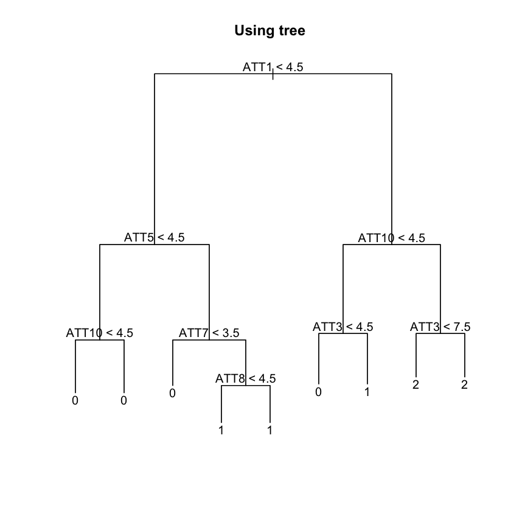

```r
tree_model <- tree(Result ~., train)
plot(tree_model); title('Using tree'); text(tree_model, pretty = 0)
```

#### Calculating the classification accuracy from the single tree

```r
calculate_missclas <- function(prediction, variable){
    acc <- (1 - mean(prediction != variable)) * 100
    return(acc)
}
```

```r
train_pred <- predict(tree_model, train, type = 'class')
train_acc <- calculate_missclas(train_pred, train$Result)

test_pred <- predict(tree_model, test, type = 'class')
test_acc <- calculate_missclas(test_pred, test$Result)
cat('The classification accuracy is for training is', train_acc,
    '% and for test set is', test_acc, '%')
```

```
The classification accuracy is for training is 49.79167 % and for test set is 48 %
```

#### Test error for both the tree

The classification accuracy is low at ~ 50% when it was used against its own training set, however it was only slightly lower at 48% upon classifying it on the test set. As it showed that it produced a low classification accuracy when testing it again its own training set, hence the model is likely to be underfitting. This is most likely due to the exclusion of the Result '3'.

### Pruning

Tree are said to be vunerable to overfitting, however it seemed that the tree was underfitting. Though the tree would still be cross validated and pruned. The cross validation of the tree will be done on the training data and the test data for minor comparison.

```r
set.seed(1234)
cv_tree <- cv.tree(tree_model, FUN = prune.misclass)

tree_pruned <- prune.misclass(tree_model, best = cv_tree$size[which.min(cv_tree$dev)])

train_pred <- predict(tree_pruned, train, type = 'class')
train_acc <- calculate_missclas(train_pred, train$Result)

test_pred <- predict(tree_pruned, test, type = 'class')
test_acc <- calculate_missclas(test_pred, test$Result)
cat('The classification accuracy is for training is', train_acc,
    '% and for test set is', test_acc, '%')
```

```
The classification accuracy is for training is 48.75 % and for test set is 46.33333 %
```

### Bagging

To construct a more powerful classification model, bagging, as the building block to trees will be used. Boostrapping can be used can be used in a different context with tree to improve the tree based learning methods. Tree usually suffer from high variance. Originally the tree is split into two halves, resulting in a case where the two halves produce different result. To reduce variance, Bagging is used to take repeated samples from the training data to generate ith different training datasets, then the model can be trained on all these datasets.

The tree are grown deep on these new training dataset and not pruned, resulting in each of these individual tree having high variance but low bias. The average is taken, hence reducing the variance.

```r
set.seed(1234)
bagging <- randomForest(Result ~., data = train, mtry = (length(train)-1), importance = TRUE,
                        ntree = 100, proximity = TRUE) # running bagged tree
train_pred <- predict(bagging, newdata = train)
train_acc <- calculate_missclas(train_pred, train$Result)

test_pred <- predict(bagging, newdata = test)
test_acc <- calculate_missclas(test_pred, test$Result)
print(bagging)
cat('\nThe classification accuracy is for training is', train_acc,
    '% and for test set is', test_acc, '%')
```

```
Call:
 randomForest(formula = Result ~ ., data = train, mtry = (length(train) -      1), importance = TRUE, ntree = 100, proximity = TRUE)
               Type of random forest: classification
                     Number of trees: 100
No. of variables tried at each split: 10

        OOB estimate of  error rate: 26.58%
Confusion matrix:
    0   1   2  3 class.error
0 734 128   1  0   0.1494786
1 136 669  62  0   0.2283737
2   0 190 316  4   0.3803922
3   0   9 108 43   0.7312500

The classification accuracy is for training is 100 % and for test set is 76 %
```

#### Visualising bagging with different number of tree

```r
plot_tree <- function(mtry_val, ntree_val){
    tree <- randomForest(Result ~., data = train, mtry = mtry_val, importance = TRUE, ntree = ntree_val)
    layout(matrix(c(1,2),nrow=1), width=c(4,1)) #layout of the graph
    par(mar=c(5,4,4,0)); plot(tree)
    par(mar=c(5,0,4,2)); plot(c(0,1), type = 'n', axes = FALSE, xlab = '') # adding legend
    legend('top', colnames(tree$err.rate), col = 1:4, cex = 0.8, fill = 1:5) # adding column names to legend
    title('Legends')
}
```

#### Visualising error and the number of tree

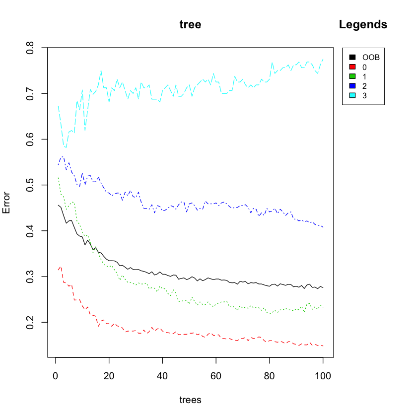

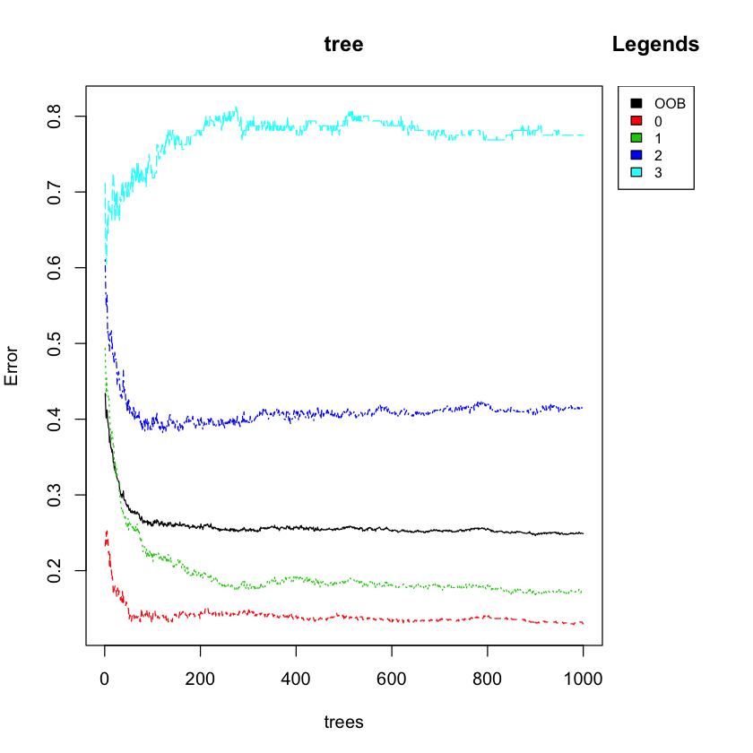

```r
plot_tree(10, 100)
plot_tree(10, 1000)
```

#### Out-of-Bag error estimation

Using the OOB approach, the tree did not need to be cross-validated, since bagging uses the concept of bootstrap and the tree are repeatedly fit to its subset. Each bagged tree uses 2/3 of the observations and the other 1/3 that was not used to fit the tree to predict the response. This is virtually equivalent to the concept of 'leave one out' cross validation error. The OOB error rate was computed on the training data set, which resulted in 26.58%, therefore there a likelihood of the bagging model accuracy to be 73.42% using 100 tree.

#### Summary bagging result

The classification accuracy for the bagging descision tree is 100% when predicting it on the training data. This is likely to be the case as more tree are created and grown deep without pruning. Although only 100 tree was used, it produced a classification accuracy of 76% for on the testing data. Also, the error rate using the test data resulted in a lower rate than the OOB estimation. Although with any bagging or random forest, the number of tree is notthe critical parameter, a descision tree bagging plot was still graphed to depict the error rate using different number of tree, at 100 and 1000.

#### MDS Plot

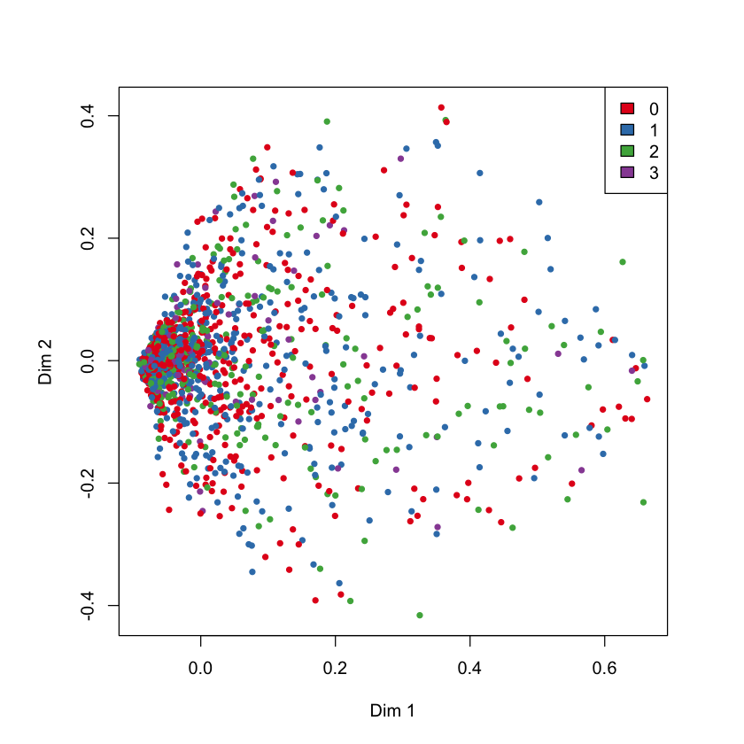

```r
MDSplot(bagging, test$Result)
legend("topright", legend = levels(train$Result), fill = brewer.pal(4, "Set1"))
```

The MDSplot, which plots the PCA of the proximity matrix. The is the matrix is the proximity measures among the input based on the frequency that pairs of the result are in the same terminal nodes. As shown in the MDS plot, a lot of the results were paired up in the same terminal node at a low dimension level, as the dimension increases, there were less overlaps. This shows that there were lots of terminal splits in the forest.

### Random Forest

Random forest uses the same concept a bagging, and that is using bootstrap to lower the variance. However it is an improvement over bagged tree as it decorrelates the trees. It does this through specificying certain values of predictors it should look at. Originally, when building a bagged tree the algorithm looks at a majority of available predictors and uses the strongest predictor, this causes all bagged tree to look similar to one another and the predictions to be highly correlated. As the reduction of the variance of uncorrelated tree is better than correlated tree, random forest uncorrelates the tree by forcing each split to consider only a subset of the predictors. In general case, the square root of the predictor is used as the paramter for mtry.

#### Building random forest

```r
set.seed(1234)
rf <- randomForest(Result ~., data = train, mtry = sqrt(length(train)), ntree = 100, proximity = TRUE)
train_pred <- predict(rf, newdata = train)
train_acc <- calculate_missclas(train_pred, train$Result) # calculate classification accuracy

test_pred <- predict(rf, newdata = test)
test_acc <- calculate_missclas(test_pred, test$Result)
cat('\nThe classification accuracy is for training is', train_acc,
    '% and for test set is', test_acc, '%\n')

cat('\nTuning the random forest to find the most suitable number of predictor (mtry)\n')
tune.rf <- tuneRF(train[,-length(train)], train$Result, stepFactor = .4, plot = FALSE) # tuning to find best mtry
rf2 <- randomForest(Result ~., data = train, mtry = 3, ntree = 100, proximity = TRUE)
train_pred <- predict(rf2, newdata = train)
train_acc <- calculate_missclas(train_pred, train$Result)

test_pred <- predict(rf2, newdata = test)
test_acc <- calculate_missclas(test_pred, test$Result)
cat('The classification accuracy is for training is', train_acc,
    '% and for test set is', test_acc, '%\n')

cat('\n\nSummary of the best random forest\n')
print(rf)
```

```
The classification accuracy is for training is 100 % and for test set is 78.5 %

Tuning the random forest to find the most suitable number of predictor (mtry)
mtry = 3  OOB error = 29.54%
Searching left ...
mtry = 8 	OOB error = 28.71%
0.02820874 0.05
Searching right ...
mtry = 1 	OOB error = 32.12%
-0.08744711 0.05
The classification accuracy is for training is 100 % and for test set is 78.16667 %


Summary of the best random forest

Call:
 randomForest(formula = Result ~ ., data = train, mtry = sqrt(length(train)),      ntree = 100, proximity = TRUE)
               Type of random forest: classification
                     Number of trees: 100
No. of variables tried at each split: 3

        OOB estimate of  error rate: 25.96%
Confusion matrix:
    0   1   2  3 class.error
0 758 104   1  0   0.1216686
1 135 682  50  0   0.2133795
2   0 210 297  3   0.4176471
3   0   6 114 40   0.7500000
```

#### Result summary

100 tree were used to build the random forest. A default square root of the number of predictor was used to train the model and this produced a training classification accuracy of 100%, but 78.5% for when classifying it on test data.

#### Visualising error and the number of tree

Only 100 tree was used, so a plot will be drawn showing the error rate on the number of tree for 100 and 1000.

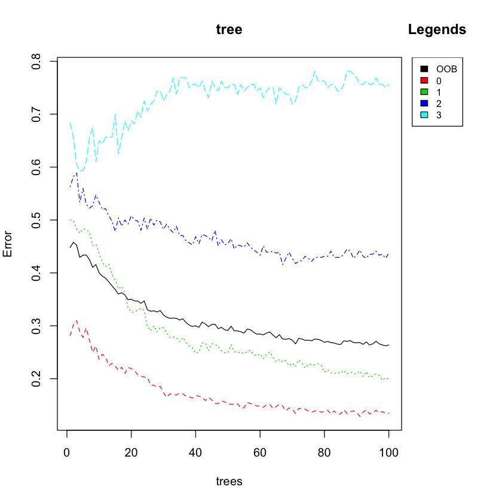

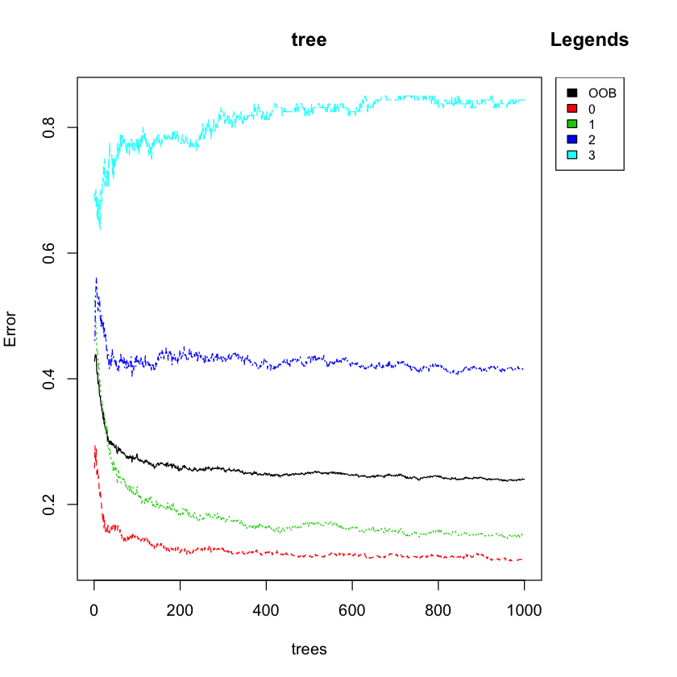

```r
plot_tree(sqrt(length(train)), 100)
plot_tree(sqrt(length(train)), 1000)
```

#### Out-of-Bag error estimation

The cross validation error rate from the summary of the best random forest was shown to be 25.96%, hence the tree have the possibility to identify correctly, approximately 74.04% of the time.

#### MDS Plot

The MDS plot also showed that in most cases, a lot of the result classes are in the same terminal node in the random forest. This occurs a lot in lower dimension.

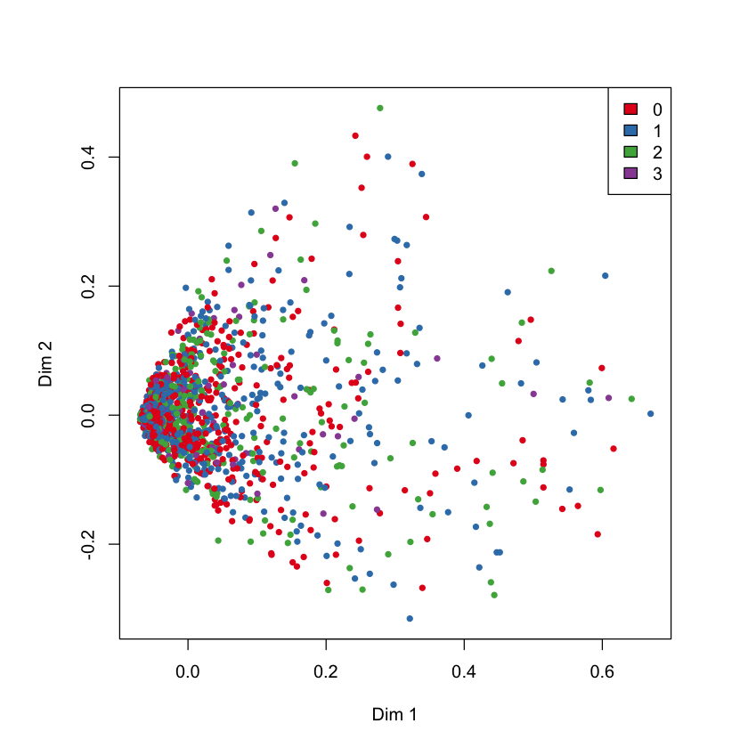

```r
MDSplot(rf, test$Result)
legend("topright", legend = levels(train$Result), fill = brewer.pal(4, "Set1"))
```

### Tree, Pruned Tree, Bagged Tree and Random Forest

The single tree and pruned tree produced the lowest accuracy of all the trees, most likely due to underfitting as result 3 was not included in any of the terminal nodes. Nevetheless, bagged and random forest included result 3, where the classification accuracy on the test data was a lot higher. Hence, Bagged Tree and Random Forest will be compared.

#### Barplot of the variable importance

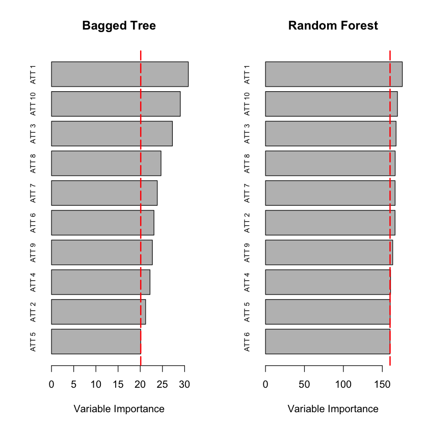

```r
par(mfrow=c(1,2))
bagImportance <- varImp(bagging, type = 1)
barplot(sort(bagImportance$Overall),
        horiz = TRUE, names.arg = paste('ATT', as.character(order(bagImportance$Overall))), cex.names = 0.7,
        xlab = 'Variable Importance')
abline(v = abs(min(bagImportance$Overall)), col='red', lty = 'longdash', lwd = 2) # adding red line
title('Bagged Tree')


rfImportance <- varImp(rf)
barplot(sort(rfImportance$Overall),
        horiz = TRUE, names.arg = paste('ATT', as.character(order(rfImportance$Overall))), cex.names = 0.7,
        xlab = 'Variable Importance') # creating barplot of the importance variable
abline(v = abs(min(rfImportance$Overal)), col='red', lty = 'longdash', lwd = 2)
title('Random Forest')
```

#### Choosing random forest

Since random forest removed the correlation, which reduces the variance within the data, and have a higher classification accuracy than bagged tree, random forest is a better classifer in this case. Hence, random forest will be used as a descision tree to classify the result of the cancer.

## 2.2 Discriminant Analysis

### Why Disriminant Analysis

First and foremost as there are more than two response classes linear discriminant analysis is usually the more preferred and popular method utilized with dealing with such a classification problem. Thus, linear discriminant analysis is ofen used as an alternative to logistic regression. In logistical regression we model the conditional distribution of the response *$Y$*, given a set of predictors *$X$*. However, in disriminant analyis the distribution of the predictors $X$ are modelled seperately in each of the response classes given $Y$ and use Baye's theorem to find the esitmates for finding the probablility that $Y$ belongs to a certain class $k$, given $X$=$x$. It does this by finding the linear combination of predictors that both maximizes the separation between the centers of the data and minimizes the variation within each group.

Parameters are estimated and then used in the Bayes classifier. The Bayes classifier assigns each observation to the most likely class given its predictor values. Essentially linear discriminant analysis is a classifier that attempts to approximate the Bayes classifier

Below, we will run the linear discriminant analysis with the imputed values.

```r
library("MASS")
library(caret)
```

```r
# Subsetting the data set by eliminating the ID
new_data = subset(dat, select = -c(ID) )
# Creating the train and test data sets
train_data <- train_test(new_data, 'train')
test_data <- train_test(new_data, 'test')
train_results <- train_data$Result
test_results <- test_data$Result
```

```r
#Setting up the LDA utilizing the MASS package
prosLDA = lda(Result ~ ., data=train_data)
prosLDA
```

```
Call:
lda(Result ~ ., data = train_data)

Prior probabilities of groups:
         0          1          2          3
0.35958333 0.36125000 0.21250000 0.06666667

Group means:
      ATT1     ATT2     ATT3     ATT4     ATT5     ATT6     ATT7     ATT8
0 3.269988 3.417149 3.304751 3.447277 3.224797 3.457706 3.360371 3.446118
1 4.467128 4.686275 4.485582 4.404844 4.332180 4.536332 4.689735 4.653979
2 5.645098 5.431373 5.564706 5.433333 5.345098 5.513725 5.480392 5.254902
3 6.500000 6.587500 6.468750 6.687500 6.381250 6.143750 6.468750 6.643750
      ATT9    ATT10
0 3.348783 3.358053
1 4.671280 4.402537
2 5.317647 5.756863
3 6.375000 6.468750

Coefficients of linear discriminants:
            LD1         LD2         LD3
ATT1  0.2629955  0.10031475 -0.04965347
ATT2  0.2509913 -0.11548875 -0.01262136
ATT3  0.2585945  0.05055023 -0.02354502
ATT4  0.2584730  0.04384342  0.27077243
ATT5  0.2615636  0.03245476  0.06699191
ATT6  0.2440161  0.06380112 -0.13694689
ATT7  0.2412122 -0.09535117 -0.13013236
ATT8  0.2598730 -0.17432571  0.14492358
ATT9  0.2535499 -0.15089304 -0.09975812
ATT10 0.2557364  0.21011552 -0.02455859

Proportion of trace:
   LD1    LD2    LD3
0.9981 0.0014 0.0005
```

Finaly, the cooeficients of the linear discrinimants output provides the linear combination of ATT1 through ATT!0 that are used to form the LDA decision rule.

### Cross validation

We now have produced a model based on Linear Discriminant Analysis. However, as is usual the training error often underestimates the actual test error rate. For this reason, we will run the model with cross-validation parameter set to true. The MASS library utilised for performing the LDA makes use of Leave One Out Cross Validaion or LOOCV. Generally, the test error is estimating by *holding out* a subset of the training observations from the fitting process, and then applying the statistical learning method, in this case LDA, to the held out observations. More specifically, in LOOCV, the LDA model is fit on to $n-1$ training observations and classification is made on the excluded observation. The LOOCV estimate for the prediction accuracy is thus an average of the preictive accuracies.

```r
#Cross Validation confusion matrix
lda.cv.confusion = confusionMatrix(train_data$Result, update(prosLDA, CV=T)$class->prosLDAcv)
lda.cv.confusion$table
lda.cv.confusion$overall["Accuracy"]
```

```
          Reference
Prediction   0   1   2   3
         0 782  81   0   0
         1   1 862   4   0
         2   0  25 485   0
         3   0   0  29 131
```

**Accuracy:** 0.941666666666667

In testing the classification accuracy in the training data through the use of LOOCV it was found that thethe LDA model produced is capable correctly classying 94.1% of the obsersvations in the training sample. It's important to note that elements in along the diagonal in the above confusion matrix are those that were correctly classified by the model. In contrast, those that lie on the off diagonal are missclassified. As wee can from the above output the LDA model did well in classifying the observations of the training set for classes 0 and 3, however there was a total of 106 missclassifcations for class 1 and 33 misclassifications for class 2.

We test the LDA model on the remiaing 20% of the data which is the test data.

```r
pred.lda = predict(prosLDA, test_data)
lda.test.confusion = confusionMatrix(pred.lda$class, test_data$Result)
lda.test.confusion
```

```
Confusion Matrix and Statistics

          Reference
Prediction   0   1   2   3
         0 205   0   0   0
         1  14 210   6   0
         2   0   3 126   5
         3   0   0   0  31

Overall Statistics

               Accuracy : 0.9533
                 95% CI : (0.9333, 0.9688)
    No Information Rate : 0.365
    P-Value [Acc > NIR] : < 2.2e-16

                  Kappa : 0.9321
 Mcnemar's Test P-Value : NA

Statistics by Class:

                     Class: 0 Class: 1 Class: 2 Class: 3
Sensitivity            0.9361   0.9859   0.9545  0.86111
Specificity            1.0000   0.9483   0.9829  1.00000
Pos Pred Value         1.0000   0.9130   0.9403  1.00000
Neg Pred Value         0.9646   0.9919   0.9871  0.99121
Prevalence             0.3650   0.3550   0.2200  0.06000
Detection Rate         0.3417   0.3500   0.2100  0.05167
Detection Prevalence   0.3417   0.3833   0.2233  0.05167
Balanced Accuracy      0.9680   0.9671   0.9687  0.93056
```

As indicated by the output above, the model produced an even hihgher classification accuracy of 95.3%. This is natural and is likely due to the fact that we are using a smaller sample in our test data. With a smaller sample $n$ it is probable that the LDA does a better job at discriminating amongst the various classes.

*Sesitivity* here is the rate of true positives found for each class. In this context, it is the percentage of observations that are correctly classified belonging to a certain class. It can be seen that the sensitivity for class 3 is the lowest amongst the three classes - indicating that the model underperforms in this context. This is further reittirated by the Balanced accuracy figure of 0.93 of that class.

### Quadratic Discriminant Analysis

We now shift our focus to trying to attempt classify the results of the observation using quadratic discriminant analysis. Similar to LDA quadratic discriminant analysis assumes that the observations are drawn from a Gaussian distribution. As mentioned earlier, LDA assumes a class-specific mean vector and a covariance matrix that is common to all $K$ classes. This is where the main difference between LDA and QDA arises. Unlike linear discriminant analyis, quadratic discriminant analysis relaxes common covariance assumption in LDA and assumes that each class has a *unique* covariance matrix.

As in the case of LDA we will utilize the MASS package to produce a QDA model hown below.

```r
prosQDA = qda(Result ~ ., data=train_data)
prosQDA
```

```
Call:
qda(Result ~ ., data = train_data)

Prior probabilities of groups:
         0          1          2          3
0.35958333 0.36125000 0.21250000 0.06666667

Group means:
      ATT1     ATT2     ATT3     ATT4     ATT5     ATT6     ATT7     ATT8
0 3.269988 3.417149 3.304751 3.447277 3.224797 3.457706 3.360371 3.446118
1 4.467128 4.686275 4.485582 4.404844 4.332180 4.536332 4.689735 4.653979
2 5.645098 5.431373 5.564706 5.433333 5.345098 5.513725 5.480392 5.254902
3 6.500000 6.587500 6.468750 6.687500 6.381250 6.143750 6.468750 6.643750
      ATT9    ATT10
0 3.348783 3.358053
1 4.671280 4.402537
2 5.317647 5.756863
3 6.375000 6.468750
```

As each class had its own covariance matrix, then the approximation of the Bayes classifier would be a quadratic equation instead of a linear one. It is for that reason that the output above doesn't portray Linear Discriminants.

We will now again cross-validate the model using the LOOCV method spoken about earlier. This will tend to give a more accurate result of classification accuracy - as using the training error alone usually underestimates the test-error.

```r
#Cross Validation using LOOCV - confusion matrix
qda.cv.confusion = confusionMatrix(train_data$Result, update(prosQDA, CV=T)$class->prosQDAcv)
qda.cv.confusion$table
qda.cv.confusion$overall["Accuracy"]
```

```
          Reference
Prediction   0   1   2   3
         0 834  29   0   0
         1  16 842   9   0
         2   0  13 489   8
         3   0   0   4 156
```

**Accuracy:** 0.967083333333333

Using the LOOCV we can observe a classification accuracy of of 96.7%. This is relatively higher than that obtained by the LDA method used previously. This is primarily due to the fact that as quadratic discriminant analysis assumes a quadratic decision boundary - it can therefore accurately classify a wider range of classes than its linear counterpart.

Running the QDA on the test data

```r
pred.qda = predict(prosQDA, test_data)
qda.test.confusion = confusionMatrix(pred.qda$class, test_data$Result)
qda.test.confusion
```

```
Confusion Matrix and Statistics

          Reference
Prediction   0   1   2   3
         0 214   5   0   0
         1   5 205   3   0
         2   0   3 127   0
         3   0   0   2  36

Overall Statistics

               Accuracy : 0.97
                 95% CI : (0.953, 0.9821)
    No Information Rate : 0.365
    P-Value [Acc > NIR] : < 2.2e-16

                  Kappa : 0.9565
 Mcnemar's Test P-Value : NA

Statistics by Class:

                     Class: 0 Class: 1 Class: 2 Class: 3
Sensitivity            0.9772   0.9624   0.9621  1.00000
Specificity            0.9869   0.9793   0.9936  0.99645
Pos Pred Value         0.9772   0.9624   0.9769  0.94737
Neg Pred Value         0.9869   0.9793   0.9894  1.00000
Prevalence             0.3650   0.3550   0.2200  0.06000
Detection Rate         0.3567   0.3417   0.2117  0.06000
Detection Prevalence   0.3650   0.3550   0.2167  0.06333
Balanced Accuracy      0.9820   0.9709   0.9779  0.99823
```

Upon running the QDA model on the test data, a quite high accuracy of 97% is observed, very similar to that obtained during the accuracy produced during the cross validation process. As previously mentioned the QDA model has outperformed the LDA model primarily due to its quadratic decision boundary.

### A comparison of LDA and QDA

Below we a comparison of the two methods and their respective results will be discussed.

```r
qda.sensi <- c( 0.9772 ,  0.9624 ,  0.9621 ,1.00000)
lda.sensi <- c(0.9361  , 0.9859  , 0.9545 , 0.86111 )
sensi.data <- data.frame(qda.sensi, lda.sensi)
rownames(sensi.data) <- c('Class 0', 'Class 1', 'Class 2', 'Class 3')
colnames(sensi.data) <- c('QDA Sensitivity', 'LDA Sensitivity')
t(sensi.data)
```

|  | Class 0 | Class 1 | Class 2 | Class 3 |
| --- | --- | --- | --- | --- |
| QDA Sensitivity | 0.9772 | 0.9624 | 0.9621 | 1.0000 |
| LDA Sensitivity | 0.93610 | 0.98590 | 0.95450 | 0.86111 |

As observed previously, QDA produced a classification accuracy of **97%** whereas LDA produced classification accuracy of approximately **95%**. This is in concurrence with the table produced above which portrays the various sensitivities for each class given the method used. We can see that the sensitivity produced by QDA for every class with the exception of Class 1 is higher - thus accounting for the higher classification accuracy of QDA.

As discussed earlier, linear discriminant analysis assumes that the observations are drawn from a multivariate Gaussian distribution and have a common covariance matrix amongst all the classes $K$. In contrast, QDA assumes relaxes this assumption and assumes that the classes have unique covariance matrices. This underlying assumption of LDA is thus much less of flexible of a classifier than QDA - as there are only $Kp$ linear coefficients to be estimated. As a result, LDA has a substantially lower variance than its QDA counter part and this could *potentially* lead to improved predictive performance. However, this was not the case with the prostate cancer data set used. The QDA model - with its quadratic decision boundaries- has outperformed the LDA.

It is likely that the classes do not share a common covariance matrix and the Bayesian decision boundary is quadratic rather than linear. It is for this reason that the QDA has more accurately approximated this boundary this yielding superior prediction accuracy than its linear counterpart.

## 2.3 Classification by SVM

The *Support Vector Machine* (SVM) is used when classification of data with multiple classes, i.e. more than two classes is required. SVM uses the all-vs-all classification approach when more than two classes in the response variable have been detected. Using a **kernel** that allows *soft vector classification*, i.e. allowing a certain limit of misclassification, data of massive sets with different classes can be seperated using the support vectors for the hyper plane. This can be done either linearly by using the **linear** kernel or non-linearly, by using the **radial** or the **polynomial** kernel. The value of cost define the threshold of misclassification permitted and for the radial kernel, value of gamma is used to specify the radial basis. These misclassification vectors are tuned to select the best when it comes to fitting the SVM on the training data set. Since the data set is supervised, a confusion matrix to test the prediction accuracy can be implemented.  
We create the train and test data sets needed for the models.

```r
# Subsetting the data set by eliminating the ID
new_data = subset(dat, select = -c(ID) )
# Creating the train and test data sets
train_data <- train_test(new_data, 'train')
test_data <- train_test(new_data, 'test')
train_results <- train_data$Result
test_results <- test_data$Result
```

```r
head(train_data)
```

|  | ATT1 | ATT2 | ATT3 | ATT4 | ATT5 | ATT6 | ATT7 | ATT8 | ATT9 | ATT10 | Result |
| --- | --- | --- | --- | --- | --- | --- | --- | --- | --- | --- | --- |
| 342 | 9 | 4 | 2 | 5 | 7 | 6 | 5 | 4 | 4 | 5 | 2 |
| 1867 | 7 | 4 | 1 | 6 | 2 | 5 | 4 | 7 | 2 | 2 | 0 |
| 1827 | 4 | 3 | 6 | 7 | 3 | 8 | 7 | 5 | 7 | 2 | 2 |
| 1869 | 9 | 4 | 2 | 6 | 1 | 9 | 5 | 9 | 2 | 9 | 2 |
| 2580 | 5 | 7 | 2 | 3 | 7 | 5 | 4 | 7 | 5 | 6 | 2 |
| 1918 | 9 | 9 | 6 | 1 | 7 | 8 | 2 | 6 | 3 | 1 | 2 |

### a. Using Linear Kernel

The *linear* kernel measures for the similarity between the variables and accordingly outputs the support vector classifier. Using a fine tuned value for cost (i.e. the margin for misclassification), the *tune()* cross validates the range of input given using the **K Fold** cross validation technique and outputs the best cost value to be used. The smaller the cost value, the larger the number of support vectors.

```r
# Tune kernel to get cost
svm_tune_linear <- tune(svm, Result ~ ., kernel = "linear", data = train_data, ranges = list(cost=10^(-1:2)))
summary(svm_tune_linear)
```

```
Parameter tuning of ‘svm’:

- sampling method: 10-fold cross validation

- best parameters:
 cost
   10

- best performance: 0.0004166667

- Detailed performance results:
   cost        error  dispersion
1   0.1 0.0245833333 0.009096957
2   1.0 0.0133333333 0.008050765
3  10.0 0.0004166667 0.001317616
4 100.0 0.0004166667 0.001317616
```

The best *cost* value is 10. The summary also states the values of cost been cross validated. This value is now used in the *svm()*

```r
# Fit the SVM for a linear kernel on the training set with the best cost as 10
linear.model <- svm(Result ~ ., data = train_data, kernel = "linear", cost = svm_tune_linear$best.parameter$cost)
summary(linear.model)
```

```
Call:
svm(formula = Result ~ ., data = train_data, kernel = "linear", cost = svm_tune_linear$best.parameter$cost)


Parameters:
   SVM-Type:  C-classification
 SVM-Kernel:  linear
       cost:  10
      gamma:  0.1

Number of Support Vectors:  368

 ( 88 76 176 28 )


Number of Classes:  4

Levels:
 0 1 2 3
```

The summary above states that the number of support vectors are **368**, and are divided among the 4 classes *0, 1, 2* and *3* in a way that 88 support vectors fall under class **0**, 76 support vectors fall under class **1**, 176 support vectors fall under class **2**, 28 support vectors fall under class **3**.

Using this SVM model, the results for the train data is predicted.

```r
# Predicting the values for the training set
train.pred <- predict(linear.model, train_data)
# Creating the confusion matrix to get the estimates and the accuracy of the prediction
train_acc = confusionMatrix(train.pred,train_results)
# Print Prediction accuracy
train_acc$overall['Accuracy']
```

**Accuracy:** 0.999583333333333

The predition accuracy for the training set is almost 100%, estimating that the train data was correctly classified. We train the model on the test data.

```r
# Predicting the values for the test set
test.pred <- predict(linear.model, test_data)
# Creating the confusion matrix to get the estimates and the accuracy of the prediction
test_acc = confusionMatrix(test.pred,test_results)
# Print the confusion matrix
test_acc
linear.test_acc = (1 - mean(test.pred!=test_results))*100
```

```
Confusion Matrix and Statistics

          Reference
Prediction   0   1   2   3
         0 219   0   0   0
         1   0 213   0   0
         2   0   0 132   0
         3   0   0   0  36

Overall Statistics

               Accuracy : 1
                 95% CI : (0.9939, 1)
    No Information Rate : 0.365
    P-Value [Acc > NIR] : < 2.2e-16

                  Kappa : 1
 Mcnemar's Test P-Value : NA

Statistics by Class:

                     Class: 0 Class: 1 Class: 2 Class: 3
Sensitivity             1.000    1.000     1.00     1.00
Specificity             1.000    1.000     1.00     1.00
Pos Pred Value          1.000    1.000     1.00     1.00
Neg Pred Value          1.000    1.000     1.00     1.00
Prevalence              0.365    0.355     0.22     0.06
Detection Rate          0.365    0.355     0.22     0.06
Detection Prevalence    0.365    0.355     0.22     0.06
Balanced Accuracy       1.000    1.000     1.00     1.00
```

The prediction accuracy for the test data again is a 100%, with a confidence interval of 0.99 to 1. The confusion matrix shows how the values predicted across the diagonal for each class is perfect, with all values being true positives. This shows that the model overfits the test data, which is undesirable. Thus, it can be safely stated that SVM with a linear kernel **cannot** be used to classify this set of data due to its perfect prediction accuracy.

### b. Radial Kernel

The *radial* kernel for **SVM** is used to classify data in a non-linear fashion. This kernel looks works *locally* by pedicting the class for the test variable by the local surrounding training observation, and not those farther away. The radial kernel uses a gamma value as a positive constant to seperate the observations non-linearly. This gamma value can also be tuned with the cost function, in order to obtain the most optimal value.

```r
# Tune kernel to get gamma and cost values
svm_tune_radial <- tune(svm, Result ~ ., kernel = "radial", data = train_data, ranges = list(cost=10^(-1:2), gamma = c(.5,1,2)))
summary(svm_tune_radial)
```

```
Parameter tuning of ‘svm’:

- sampling method: 10-fold cross validation

- best parameters:
 cost gamma
   10   0.5

- best performance: 0.1808333

- Detailed performance results:
    cost gamma     error dispersion
1    0.1   0.5 0.5104167 0.04074206
2    1.0   0.5 0.2045833 0.02368860
3   10.0   0.5 0.1808333 0.02470505
4  100.0   0.5 0.1808333 0.02470505
5    0.1   1.0 0.6641667 0.02592427
6    1.0   1.0 0.3920833 0.02929535
7   10.0   1.0 0.3687500 0.03038145
8  100.0   1.0 0.3687500 0.03038145
9    0.1   2.0 0.6641667 0.02592427
10   1.0   2.0 0.4795833 0.05758280
11  10.0   2.0 0.4625000 0.04976798
12 100.0   2.0 0.4625000 0.04976798
```

As seen, the optimal values for the **cost** and **gamma** parameter are 10 and 0.5 respectively. The *Detailed Performance Results* show the cross validation conducted to select the best values. Using these values, the parameters for the radial kernel for SVM are set and fitted on the training set.

```r
# Fit the SVM for a radial kernel on the training set with the best cost as 10 and gamma as 0.5
radial.model <- svm(Result ~ ., data = train_data, kernel = "radial", cost = svm_tune_radial$best.parameter$cost, gamma = svm_tune_radial$best.parameter$gamma)
summary(radial.model)
```

```
Call:
svm(formula = Result ~ ., data = train_data, kernel = "radial", cost = svm_tune_radial$best.parameter$cost,
    gamma = svm_tune_radial$best.parameter$gamma)


Parameters:
   SVM-Type:  C-classification
 SVM-Kernel:  radial
       cost:  10
      gamma:  0.5

Number of Support Vectors:  2077

 ( 507 572 838 160 )


Number of Classes:  4

Levels:
 0 1 2 3
```

Just as for the linear kernel, SVM produces an output showing that the number of support vectors is 2077, which is higher than the support vetor with a linear kernel. Of these support vectors, 507 of them are under the class **0**, 572 are under class **1**, 838 are under class **2** and 160 are classified under **3**. Using the fit model for the radial kernel, values for the train data are predicted to understand the prediction accuracy.

```r
# Predicting the values for the training set
train.pred <- predict(radial.model, train_data)
# Creating the confusion matrix to get the estimates and the accuracy of the prediction
train_acc <- confusionMatrix(train.pred,train_results)
# Print Prediction accuracy
train_acc$overall['Accuracy']
```

**Accuracy:** 1

The fit radial SVM is fit on the test set to obtain the prediction accuracy for the classification.

```r
# Predicting the values for the test set
test.pred <- predict(radial.model, test_data)
# Creating the confusion matrix to get the estimates and the accuracy of the prediction
test_acc = confusionMatrix(test.pred,test_results)
# Print the confusion matrix
test_acc
radial.test_acc = (1 - mean(test.pred!=test_results))*100
```

```
Confusion Matrix and Statistics

          Reference
Prediction   0   1   2   3
         0 189  12   0   0
         1  30 190  34   1
         2   0  11  97  20
         3   0   0   1  15

Overall Statistics

               Accuracy : 0.8183
                 95% CI : (0.7851, 0.8484)
    No Information Rate : 0.365
    P-Value [Acc > NIR] : < 2.2e-16

                  Kappa : 0.7322
 Mcnemar's Test P-Value : NA

Statistics by Class:

                     Class: 0 Class: 1 Class: 2 Class: 3
Sensitivity            0.8630   0.8920   0.7348  0.41667
Specificity            0.9685   0.8320   0.9338  0.99823
Pos Pred Value         0.9403   0.7451   0.7578  0.93750
Neg Pred Value         0.9248   0.9333   0.9258  0.96404
Prevalence             0.3650   0.3550   0.2200  0.06000
Detection Rate         0.3150   0.3167   0.1617  0.02500
Detection Prevalence   0.3350   0.4250   0.2133  0.02667
Balanced Accuracy      0.9158   0.8620   0.8343  0.70745
```

As seen, the prediction accuracy for the radial kernel is lower than that of the linear kernel and its own training prediction accuracy. There are certain variables that have been misclassified, as seen in the confusion matrix. Although the prediction accuracy seems acceptable, the test is fit based on the training data, which produced an accuracy of a 100% for the train set. This indicates overfittimg, just like for the linear kernel. Thus, this model can't be relied on to classify the test set too. Thus, the hunt for the most optimal model continues.

### c. Polynomial Kernel

The *polynomial* kernel is another form of a non-linear kernel for SVM which helps produce a flexible boundary for the classifiers. Instead of quantifying the similarity of 2 variables with a single power creating a rigid boundary for the variables, raising the kernel to the power of a higher number (not more than 4, to avoid over-fitting), the margin boundaries are made flexible enough to accomodate non-linear data. We test the classification using the polynomial kernel on the data set provided.

In order to conduct a *polynomial* kernel classification, two degrees of the kernel are tested: polynomial of degree 2 and of degree 3. This is done in order to understand and select the best degree that can be used. Using a polynomial of degree over 4 would end up in over fitting, which needs to be avoided.  
The *tune()* is used to select the best cost value for the kernel, allowing a certain amount of misclassification.

```r
# Tune kernel to get cost values for the degree 2
tune.out.2 <- tune(svm, Result ~ ., data = train_data, kernel = "polynomial", degree = 2, ranges = list(cost = 10^seq(-2, 1, by = 0.25)))
summary(tune.out.2)
```

```
Parameter tuning of ‘svm’:

- sampling method: 10-fold cross validation

- best parameters:
 cost
   10

- best performance: 0.2479167

- Detailed performance results:
          cost     error dispersion
1   0.01000000 0.5962500 0.05574447
2   0.01778279 0.5616667 0.04417453
3   0.03162278 0.5275000 0.03865006
4   0.05623413 0.4912500 0.03950162
5   0.10000000 0.4487500 0.04011221
6   0.17782794 0.3929167 0.03632681
7   0.31622777 0.3533333 0.03512544
8   0.56234133 0.3170833 0.04196422
9   1.00000000 0.2962500 0.03120831
10  1.77827941 0.2741667 0.02951511
11  3.16227766 0.2595833 0.02743187
12  5.62341325 0.2537500 0.03089771
13 10.00000000 0.2479167 0.02980453
```

Using this tuned cost value of 10, the SVM model for the polynomial kernel is fit on the training data

```r
# Fit the SVM for a polynomial kernel on the training set with the best cost as 10 and polynomial of degree 2
svm.poly.2 <- svm(Result ~ ., kernel = "polynomial", degree = 2, data = train_data, cost = tune.out.2$best.parameter$cost)
summary(svm.poly.2)
```

```
Call:
svm(formula = Result ~ ., data = train_data, kernel = "polynomial",
    degree = 2, cost = tune.out.2$best.parameter$cost)


Parameters:
   SVM-Type:  C-classification
 SVM-Kernel:  polynomial
       cost:  10
     degree:  2
      gamma:  0.1
     coef.0:  0

Number of Support Vectors:  1342

 ( 441 526 282 93 )


Number of Classes:  4

Levels:
 0 1 2 3
```

The polynomial fit shows that there are 1342 support vectors with them divides as 441 support vectors classified under class **0**, 526 as class **1**, 282 as class **2** and 93 as class **3**. Using the fit model, the training data set can be predicted for the class values.

```r
# Predicting the values for the training set
train.pred <- predict(svm.poly.2, train_data)
# Creating the confusion matrix to get the estimates and the accuracy of the prediction
train_acc <- confusionMatrix(train.pred,train_results)
# Print Prediction accuracy
train_acc$overall['Accuracy']
```

**Accuracy:** 0.78875

The same is now done to predict and check the prediction accuracy for the test data.

```r
# Predicting the values for the test set
test.pred.2 <- predict(svm.poly.2, test_data)
# Creating the confusion matrix to get the estimates and the accuracy of the prediction
test_acc <- confusionMatrix(test.pred.2,test_results)
# Print Prediction accuracy
test_acc
poly2.test_acc = (1- mean(test.pred.2!=test_results))*100
```

```
Confusion Matrix and Statistics

          Reference
Prediction   0   1   2   3
         0 162   3  55  10
         1  31 207   2   0
         2  24   3  75   4
         3   2   0   0  22

Overall Statistics

               Accuracy : 0.7767
                 95% CI : (0.7412, 0.8094)
    No Information Rate : 0.365
    P-Value [Acc > NIR] : < 2.2e-16

                  Kappa : 0.67
 Mcnemar's Test P-Value : NA

Statistics by Class:

                     Class: 0 Class: 1 Class: 2 Class: 3
Sensitivity            0.7397   0.9718   0.5682  0.61111
Specificity            0.8215   0.9147   0.9338  0.99645
Pos Pred Value         0.7043   0.8625   0.7075  0.91667
Neg Pred Value         0.8459   0.9833   0.8846  0.97569
Prevalence             0.3650   0.3550   0.2200  0.06000
Detection Rate         0.2700   0.3450   0.1250  0.03667
Detection Prevalence   0.3833   0.4000   0.1767  0.04000
Balanced Accuracy      0.7806   0.9433   0.7510  0.80378
```

As compared to the linear and radial kernels, the polynomial kernel gives a much lower prediction accuracy of 77%. Based on the confusion matrix, it is evident that each class has values that have been misclassified. Although based on the sensitivity, class 1 was best classified, as compared to class 2 which has the lowest sensitivity. Although, the pediction accuracy for the polynomial kernel seems to be less than the linear or the radial kernel, it has the value that is acceptable since it does not overfit of the model on the test data but producing an almost perfect prediction accuracy.  
This model was fit for a 2 degree polynomial. Following is the similar procedure but with a third degree polynomial kernel. Before fitting the model, the best cost value is achieved by tuning it for the degree 3.

```r
# Tune the model for best cost value
tune.out.3 <- tune(svm, Result ~ ., data = train_data, kernel = "polynomial", degree = 3, ranges = list(cost = 10^seq(-2,1, by = 0.25)))
summary(tune.out.3)
```

```
Parameter tuning of ‘svm’:

- sampling method: 10-fold cross validation

- best parameters:
 cost
   10

- best performance: 0.1320833

- Detailed performance results:
          cost     error dispersion
1   0.01000000 0.6229167 0.01966639
2   0.01778279 0.5275000 0.05552777
3   0.03162278 0.4158333 0.03761813
4   0.05623413 0.2708333 0.02476744
5   0.10000000 0.1983333 0.02366823
6   0.17782794 0.1633333 0.01808758
7   0.31622777 0.1537500 0.02269038
8   0.56234133 0.1408333 0.01991494
9   1.00000000 0.1445833 0.01757370
10  1.77827941 0.1412500 0.01847274
11  3.16227766 0.1395833 0.01834701
12  5.62341325 0.1341667 0.02048788
13 10.00000000 0.1320833 0.02134104
```

Just as in for degree 2 polynomial, the best cost value by cross validation is 10

```r
# Fit the SVM for a polynomial kernel on the training set with the best cost as 10 and polynomial of degree 3
svm.poly.3 <- svm(Result ~ ., kernel = "polynomial", degree = 3, data = train_data, cost = tune.out.3$best.parameter$cost)
summary(svm.poly.3)
```

```
Call:
svm(formula = Result ~ ., data = train_data, kernel = "polynomial",
    degree = 3, cost = tune.out.3$best.parameter$cost)


Parameters:
   SVM-Type:  C-classification
 SVM-Kernel:  polynomial
       cost:  10
     degree:  3
      gamma:  0.1
     coef.0:  0

Number of Support Vectors:  825

 ( 220 187 369 49 )


Number of Classes:  4

Levels:
 0 1 2 3
```

As compared to the 2nd degree polynomial kernel, the 3rd degree polynomial kernel produces 825 support vectors, with 220 classified under class **0**, 187 as class **1**, 369 as class **2** and 49 as class **3**. These support vectors are lower than that of the 2 degree polynomial, which is good since lower number of support vectors indicate faster and better classification. Using this model, the training data set is predicted to find the prediction accuracy.

```r
# Predicting the values for the training set
train.pred <- predict(svm.poly.3, train_data)
# Creating the confusion matrix to get the estimates and the accuracy of the prediction
train_acc <- confusionMatrix(train.pred,train_results)
# Print Prediction accuracy
train_acc$overall['Accuracy']
```

**Accuracy:** 0.969166666666667

Similarly, the test data set is predited using the third degree polynomial kernel.

```r
# Predicting the values for the test error
test.pred.3 <- predict(svm.poly.3, test_data)
# Creating the confusion matrix to get the estimates and the accuracy of the prediction
test_acc <- confusionMatrix(test.pred.3,test_results)
# Print Prediction accuracy
test_acc
poly3.test_acc = (1- mean(test.pred.3!=test_results))*100
```

```
Confusion Matrix and Statistics

          Reference
Prediction   0   1   2   3
         0 208  14   0   0
         1  11 180   9   0
         2   0  19 118   5
         3   0   0   5  31

Overall Statistics

               Accuracy : 0.895
                 95% CI : (0.8677, 0.9184)
    No Information Rate : 0.365
    P-Value [Acc > NIR] : < 2.2e-16

                  Kappa : 0.848
 Mcnemar's Test P-Value : NA

Statistics by Class:

                     Class: 0 Class: 1 Class: 2 Class: 3
Sensitivity            0.9498   0.8451   0.8939  0.86111
Specificity            0.9633   0.9483   0.9487  0.99113
Pos Pred Value         0.9369   0.9000   0.8310  0.86111
Neg Pred Value         0.9709   0.9175   0.9694  0.99113
Prevalence             0.3650   0.3550   0.2200  0.06000
Detection Rate         0.3467   0.3000   0.1967  0.05167
Detection Prevalence   0.3700   0.3333   0.2367  0.06000
Balanced Accuracy      0.9565   0.8967   0.9213  0.92612
```

```r
Polynomial.degree = c(2,3)
Prediction.accuracy = c(poly2.test_acc, poly3.test_acc)
Support.vectors = c(svm.poly.2$tot.nSV, svm.poly.3$tot.nSV)
poly_svm = data.frame(Polynomial.degree, Prediction.accuracy, Support.vectors)
poly_svm
```

|  | Polynomial.degree | Prediction.accuracy | Support.vectors |
| --- | --- | --- | --- |
| 1 | 2.00000 | 77.66667 | 1342.00000 |
| 2 | 3.0 | 89.5 | 825.0 |

As seen, the third degree polynomial for the SVM kernel produces a better prediction accuracy and lower support vectors than the second degree polynomial kernel. Thus, the most optimal polynomial to select would be the **Third degree** polynomial kernel.

### Best SVM Kernel

For each kernel type for SVM, the prediction accuracies have been calculated and can all be compared as follows

```r
Kernel = c('Linear Kernel', 'Radial Kernel', 'Polynomial Kernel of degree 3')
No.Support.Vectors = c(linear.model$tot.nSV, radial.model$tot.nSV, svm.poly.3$tot.nSV)
Prediction.Accuracy = c(linear.test_acc, radial.test_acc, poly3.test_acc)
SVM.Frame = data.frame(Kernel, No.Support.Vectors, Prediction.Accuracy)
SVM.Frame
```

|  | Kernel | No.Support.Vectors | Prediction.Accuracy |
| --- | --- | --- | --- |
| 1 | Linear Kernel | 368 | 100 |
| 2 | Radial Kernel | 2077 | 81.8333333333333 |
| 3 | Polynomial Kernel of degree 3 | 825 | 89.5 |

## 2.4. KNN Classification

Another method of classification that could be considered for a multi-class data set is the **K Nearest Neighbours**, otherwise known as **KNN**, where the test observation is allotted to a specific class based on the probabilities of the class of k nearest training observations. In order to learn more from the classification of the cancer data set, KNN is implemented by splitting the data to a train set, a test set and a target class set that contains the *Result* column.

```r
# Creating train set
knn_train <- train_test(new_data, 'train')
# Creating test set
knn_test <- train_test(new_data, 'test')
# Target variable train set
knn_target_train <- knn_train$Result
# Target variable test set
knn_target_test <- knn_test$Result

knn_train <- subset(knn_train, select = -Result)
knn_test <- subset(knn_test, select = -Result)
```

The value of *K* determines the number of training observations that will be considered as nearest neighbours. As a rule of thumb, the value can be the square root of the number of observations. Using this rule, the value of *K* is set accordingly for the **knn()**.

```r
# Value of K set by the square root of the total number of observations, which is 3000
k <- sqrt(nrow(new_data))
# Rounding off the value of K to the upper bound
ceiling(k)
```

55

The odd value of *K* will help in eliminating any possibilities of a tie. Using this value of k, the model is fit

```r
# Fitting the KNN model on the test data using the training observations for 55 nearest neighbors
knn_model <- knn(train = knn_train, test = knn_test, cl = knn_target_train, k)
# Compare the predicted values with the original target test
confusionMatrix(knn_target_test, knn_model)
```

```
Confusion Matrix and Statistics

          Reference
Prediction   0   1   2   3
         0 211   8   0   0
         1  25 187   1   0
         2   0  76  56   0
         3   0   0  33   3

Overall Statistics

               Accuracy : 0.7617
                 95% CI : (0.7255, 0.7952)
    No Information Rate : 0.4517
    P-Value [Acc > NIR] : < 2.2e-16

                  Kappa : 0.6404
 Mcnemar's Test P-Value : NA

Statistics by Class:

                     Class: 0 Class: 1 Class: 2 Class: 3
Sensitivity            0.8941   0.6900  0.62222  1.00000
Specificity            0.9780   0.9210  0.85098  0.94472
Pos Pred Value         0.9635   0.8779  0.42424  0.08333
Neg Pred Value         0.9344   0.7829  0.92735  1.00000
Prevalence             0.3933   0.4517  0.15000  0.00500
Detection Rate         0.3517   0.3117  0.09333  0.00500
Detection Prevalence   0.3650   0.3550  0.22000  0.06000
Balanced Accuracy      0.9360   0.8055  0.73660  0.97236
```

The confusion matrix specifies that there are some variables from the test set were misclassified, producing a Prediction accuracy of 76.1%. This is comparatively low. In order to experiment on the accuracies for different values ok *K*, the following can be done.

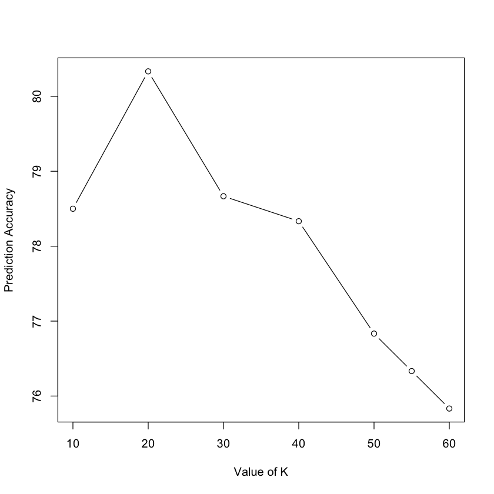

```r
accuracy <- NULL # List to store the accuracies
k <- c(10,20,30,40,50,55,60) # Different values of K, including 55 as suggested by the thumb rule
for(x in k)
{
  prediction <- knn(train = knn_train, test = knn_test, cl = knn_target_train, x)
  accuracy <- c(accuracy, (mean(prediction == knn_target_test)*100))
}
plot(k, accuracy, type = 'b', xlab = "Value of K", ylab = "Prediction Accuracy")
```

The above plot produces results showing the best prediction accuracy that could be considered. It is evident that **knn()** with **K** value as 20 produces a better prediction accuracy than that of **K** as 55. Thus, replacing the value of **K**, the **knn()** can be fit again.

```r
# Fitting the KNN model on the test data using the training observations for 55 nearest neighbors
knn_model <- knn(train = knn_train, test = knn_test, cl = knn_target_train, k = 20)
# Compare the predicted values with the original target test
confusionMatrix(knn_target_test, knn_model)
```

```
Confusion Matrix and Statistics

          Reference
Prediction   0   1   2   3
         0 207  12   0   0
         1  27 181   5   0
         2   0  49  83   0
         3   0   0  27   9

Overall Statistics

               Accuracy : 0.8
                 95% CI : (0.7657, 0.8313)
    No Information Rate : 0.4033
    P-Value [Acc > NIR] : < 2.2e-16

                  Kappa : 0.7021
 Mcnemar's Test P-Value : NA

Statistics by Class:

                     Class: 0 Class: 1 Class: 2 Class: 3
Sensitivity            0.8846   0.7479   0.7217   1.0000
Specificity            0.9672   0.9106   0.8990   0.9543
Pos Pred Value         0.9452   0.8498   0.6288   0.2500
Neg Pred Value         0.9291   0.8424   0.9316   1.0000
Prevalence             0.3900   0.4033   0.1917   0.0150
Detection Rate         0.3450   0.3017   0.1383   0.0150
Detection Prevalence   0.3650   0.3550   0.2200   0.0600
Balanced Accuracy      0.9259   0.8293   0.8104   0.9772
```

## Model Selection

### 1. K Nearest Neighbors

**Advantages** The advanatge of using KNN is that it does not assume the class of the test variable, rather it is classified based on the neighboring training values and their corresponding classes. KNN only worries about the local neighbors for each training value and thus calculated the distance for local neighbors/variables alone

**Disadvantages** In order to conduct the classifications on each of the test varaibles, the value of **K** needs to be determined. An incorrect selection of the **K** value can throw the bias-variance of the classification trade-off off balance. Also, the calculation of the distances between two neighbors will be computationally expensive if the training data is big. Thus, bigger the training set, slower is the computation time. KNN is very sensitive to outliers, or misclassified training variables and can end up misclassifying the individual test variables.

### 2. Random Forest

**Adavantages** Random has a lot of advantages and one of it is that it is a non-parametric method, hence there is no need to worry about the dataset having outliers, however one of the major advantage is that the dataset does not have to be linearly seperable. The laboratory dataset does not have any correlation, hence this dataset is suitable as it has no linear or any noticable correlations. One major advantage of Random forest is that it uses the concept of boostrap to reduce variance while maintaining the same bias, hence there are no bias and variance tradeoff.

**Disadvantages** One major disadvantage of random forest is that when there are few tree, it is prone to overfit to the noise of the dataset. Hence if there are lots of noise rather than signal in the dataset, random forest cannot handle it well. Due to this the dataset has to not have large number of irrelevant features. As more tree are added, the tendency to overfit decreases, however has a trade off with computational time. Hence, growing the tree is rather slow compared to other methods, that is, when ntree is relatively large.

## References:

[1] - https://www.analyticsvidhya.com/blog/2016/03/tutorial-powerful-packages-imputing-missing-values/

[2] - http://www.bu.edu/sph/files/2014/05/Marina-tech-report.pdf

[3] - http://www.ssc.upenn.edu/~allison/MultInt99.pdf

[4] - https://explorable.com/statistical-correlation

[5] - https://prostate-cancer.canceraustralia.gov.au/statistics